# Supervised Learning - Foundations Project: ReCell

## Problem Statement

### Business Context

Buying and selling used phones and tablets used to be something that happened on a handful of online marketplace sites. But the used and refurbished device market has grown considerably over the past decade, and a new IDC (International Data Corporation) forecast predicts that the used phone market would be worth \$52.7bn by 2023 with a compound annual growth rate (CAGR) of 13.6% from 2018 to 2023. This growth can be attributed to an uptick in demand for used phones and tablets that offer considerable savings compared with new models.

Refurbished and used devices continue to provide cost-effective alternatives to both consumers and businesses that are looking to save money when purchasing one. There are plenty of other benefits associated with the used device market. Used and refurbished devices can be sold with warranties and can also be insured with proof of purchase. Third-party vendors/platforms, such as Verizon, Amazon, etc., provide attractive offers to customers for refurbished devices. Maximizing the longevity of devices through second-hand trade also reduces their environmental impact and helps in recycling and reducing waste. The impact of the COVID-19 outbreak may further boost this segment as consumers cut back on discretionary spending and buy phones and tablets only for immediate needs.

### Objective

The rising potential of this comparatively under-the-radar market fuels the need for an ML-based solution to develop a dynamic pricing strategy for used and refurbished devices. ReCell, a startup aiming to tap the potential in this market, has hired you as a data scientist. They want you to analyze the data provided and build a linear regression model to predict the price of a used phone/tablet and identify factors that significantly influence it.

### Data Description

The data contains the different attributes of used/refurbished phones and tablets. The data was collected in the year 2021. The detailed data dictionary is given below.

- brand_name: Name of manufacturing brand
- os: OS on which the device runs
- screen_size: Size of the screen in cm
- 4g: Whether 4G is available or not
- 5g: Whether 5G is available or not
- main_camera_mp: Resolution of the rear camera in megapixels
- selfie_camera_mp: Resolution of the front camera in megapixels
- int_memory: Amount of internal memory (ROM) in GB
- ram: Amount of RAM in GB
- battery: Energy capacity of the device battery in mAh
- weight: Weight of the device in grams
- release_year: Year when the device model was released
- days_used: Number of days the used/refurbished device has been used
- normalized_new_price: Normalized price of a new device of the same model in euros
- normalized_used_price: Normalized price of the used/refurbished device in euros

## Importing necessary libraries

```python
# Libraries to help with reading and manipulating data
import numpy as np
import pandas as pd

# Libraries to help with data visualization
import matplotlib.pyplot as plt
import seaborn as sns

sns.set()

# split the data into train and test
from sklearn.model_selection import train_test_split

# to build linear regression_model
import statsmodels.api as sm

# to check model performance
from sklearn.metrics import mean_absolute_error, mean_squared_error, r2_score
```

## Loading the dataset

```python
data=pd.read_csv("used_device_data.csv")
```

## Data Overview

The initial steps to get an overview of any dataset is to:

1. observe the first few rows of the dataset, to check whether the dataset has been loaded properly or not get information about the number of rows and columns in the dataset
2. find out the data types of the columns to ensure that data is stored in the preferred format and the value of each property is as expected.
3. check the statistical summary of the dataset to get an overview of the numerical columns of the data

```python
data.head()
```

|  | brand_name | os | screen_size | 4g | 5g | main_camera_mp | selfie_camera_mp | int_memory | ram | battery | weight | release_year | days_used | normalized_used_price | normalized_new_price |
| --- | --- | --- | --- | --- | --- | --- | --- | --- | --- | --- | --- | --- | --- | --- | --- |
| 0 | Honor | Android | 14.50 | yes | no | 13.0 | 5.0 | 64.0 | 3.0 | 3020.0 | 146.0 | 2020 | 127 | 4.307572 | 4.715100 |
| 1 | Honor | Android | 17.30 | yes | yes | 13.0 | 16.0 | 128.0 | 8.0 | 4300.0 | 213.0 | 2020 | 325 | 5.162097 | 5.519018 |
| 2 | Honor | Android | 16.69 | yes | yes | 13.0 | 8.0 | 128.0 | 8.0 | 4200.0 | 213.0 | 2020 | 162 | 5.111084 | 5.884631 |
| 3 | Honor | Android | 25.50 | yes | yes | 13.0 | 8.0 | 64.0 | 6.0 | 7250.0 | 480.0 | 2020 | 345 | 5.135387 | 5.630961 |
| 4 | Honor | Android | 15.32 | yes | no | 13.0 | 8.0 | 64.0 | 3.0 | 5000.0 | 185.0 | 2020 | 293 | 4.389995 | 4.947837 |

- The dataset contains information about different used phones/tablet.
- device type contains phones and tablets.

```python
data.shape
```

```
(3454, 15)
```

- The dataset contains information (15 attributes) about 3454 rows

```python
data.info()
```

```
<class 'pandas.core.frame.DataFrame'>
RangeIndex: 3454 entries, 0 to 3453
Data columns (total 15 columns):
 #   Column                 Non-Null Count  Dtype
---  ------                 --------------  -----
 0   brand_name             3454 non-null   object
 1   os                     3454 non-null   object
 2   screen_size            3454 non-null   float64
 3   4g                     3454 non-null   object
 4   5g                     3454 non-null   object
 5   main_camera_mp         3275 non-null   float64
 6   selfie_camera_mp       3452 non-null   float64
 7   int_memory             3450 non-null   float64
 8   ram                    3450 non-null   float64
 9   battery                3448 non-null   float64
 10  weight                 3447 non-null   float64
 11  release_year           3454 non-null   int64
 12  days_used              3454 non-null   int64
 13  normalized_used_price  3454 non-null   float64
 14  normalized_new_price   3454 non-null   float64
dtypes: float64(9), int64(2), object(4)
memory usage: 404.9+ KB
```

- There are 11 numeric (*float* and *int* type) and 4 string (*object* type) columns in the data
- The target variable is the normalized_used_price of phone/tablet, which is of *float* type

```python
data.describe(include="all").T
```

|  | count | unique | top | freq | mean | std | min | 25% | 50% | 75% | max |
| --- | --- | --- | --- | --- | --- | --- | --- | --- | --- | --- | --- |
| brand_name | 3454 | 34 | Others | 502 | NaN | NaN | NaN | NaN | NaN | NaN | NaN |
| os | 3454 | 4 | Android | 3214 | NaN | NaN | NaN | NaN | NaN | NaN | NaN |
| screen_size | 3454.0 | NaN | NaN | NaN | 13.713115 | 3.80528 | 5.08 | 12.7 | 12.83 | 15.34 | 30.71 |
| 4g | 3454 | 2 | yes | 2335 | NaN | NaN | NaN | NaN | NaN | NaN | NaN |
| 5g | 3454 | 2 | no | 3302 | NaN | NaN | NaN | NaN | NaN | NaN | NaN |
| main_camera_mp | 3275.0 | NaN | NaN | NaN | 9.460208 | 4.815461 | 0.08 | 5.0 | 8.0 | 13.0 | 48.0 |
| selfie_camera_mp | 3452.0 | NaN | NaN | NaN | 6.554229 | 6.970372 | 0.0 | 2.0 | 5.0 | 8.0 | 32.0 |
| int_memory | 3450.0 | NaN | NaN | NaN | 54.573099 | 84.972371 | 0.01 | 16.0 | 32.0 | 64.0 | 1024.0 |
| ram | 3450.0 | NaN | NaN | NaN | 4.036122 | 1.365105 | 0.02 | 4.0 | 4.0 | 4.0 | 12.0 |
| battery | 3448.0 | NaN | NaN | NaN | 3133.402697 | 1299.682844 | 500.0 | 2100.0 | 3000.0 | 4000.0 | 9720.0 |
| weight | 3447.0 | NaN | NaN | NaN | 182.751871 | 88.413228 | 69.0 | 142.0 | 160.0 | 185.0 | 855.0 |
| release_year | 3454.0 | NaN | NaN | NaN | 2015.965258 | 2.298455 | 2013.0 | 2014.0 | 2015.5 | 2018.0 | 2020.0 |
| days_used | 3454.0 | NaN | NaN | NaN | 674.869716 | 248.580166 | 91.0 | 533.5 | 690.5 | 868.75 | 1094.0 |
| normalized_used_price | 3454.0 | NaN | NaN | NaN | 4.364712 | 0.588914 | 1.536867 | 4.033931 | 4.405133 | 4.7557 | 6.619433 |
| normalized_new_price | 3454.0 | NaN | NaN | NaN | 5.233107 | 0.683637 | 2.901422 | 4.790342 | 5.245892 | 5.673718 | 7.847841 |

- normalized_used_price varies from 1.537 to 6.619
- top os used on the phones/tablets from data set is Android
- average normalized_used_price is 4.365
- Max screen_size is 30.710cm - which tends us to belive the data is for tablet.

```python
data.duplicated().sum()
```

```
0
```

- There are no duplicate values in the data

```python
data.isnull().sum()
```

```
brand_name                 0
os                         0
screen_size                0
4g                         0
5g                         0
main_camera_mp           179
selfie_camera_mp           2
int_memory                 4
ram                        4
battery                    6
weight                     7
release_year               0
days_used                  0
normalized_used_price      0
normalized_new_price       0
dtype: int64
```

- There are missing values in many columns.

## Exploratory Data Analysis (EDA)

- EDA is an important part of any project involving data.
- It is important to investigate and understand the data better before building a model with it.
- A few questions have been mentioned below which will help you approach the analysis in the right manner and generate insights from the data.
- A thorough analysis of the data, in addition to the questions mentioned below, should be done.

**Questions**:

1. What does the distribution of normalized used device prices look like?
2. What percentage of the used device market is dominated by Android devices?
3. The amount of RAM is important for the smooth functioning of a device. How does the amount of RAM vary with the brand?
4. A large battery often increases a device's weight, making it feel uncomfortable in the hands. How does the weight vary for phones and tablets offering large batteries (more than 4500 mAh)?
5. Bigger screens are desirable for entertainment purposes as they offer a better viewing experience. How many phones and tablets are available across different brands with a screen size larger than 6 inches?
6. A lot of devices nowadays offer great selfie cameras, allowing us to capture our favorite moments with loved ones. What is the distribution of devices offering greater than 8MP selfie cameras across brands?
7. Which attributes are highly correlated with the normalized price of a used device?

##### 1. What does the distribution of normalized used device prices look like?

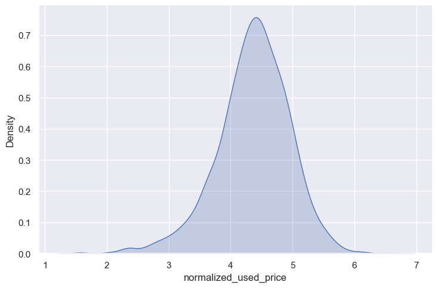

```python
sns.displot(data=data,x=data['normalized_used_price'],kind='kde', fill=True, palette=sns.color_palette('bright')[:4], height=5, aspect=1.5)
plt.show()
```

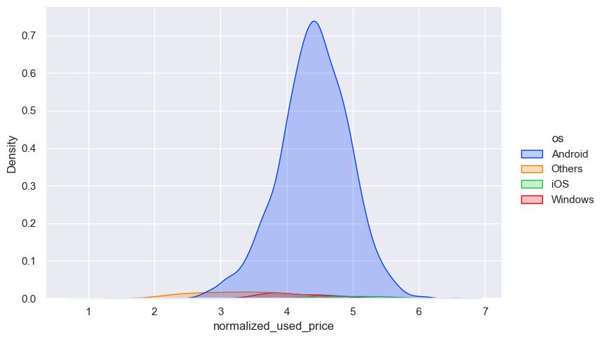

```python
sns.displot(data=data,x=data['normalized_used_price'],hue='os',kind='kde', fill=True, palette=sns.color_palette('bright')[:4], height=5, aspect=1.5)
plt.show()
```

- Distribution of normalized used device prices looks like the average is somewhere around 4.4 round off with Android being the top OS.

##### 2. What percentage of the used device market is dominated by Android devices?

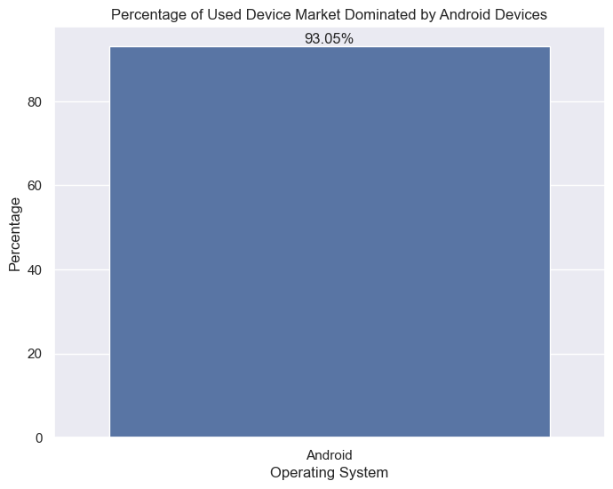

```python
df = data.copy()

# Calculate the total number of devices
total_devices = len(df)

# Calculate the number of Android devices
android_devices = len(df[df['os'] == 'Android'])

# Calculate the percentage of Android devices
percentage_android = (android_devices / total_devices) * 100

# Create a barplot
fig, ax = plt.subplots(figsize=(8, 6))
sns.barplot(x=['Android'], y=[percentage_android], ax=ax)

# Add percentage labels to the plot
ax.text(0, percentage_android, f"{percentage_android:.2f}%", ha='center', va='bottom')

# Set plot labels and title
ax.set_xlabel('Operating System')
ax.set_ylabel('Percentage')
ax.set_title('Percentage of Used Device Market Dominated by Android Devices')

plt.show()
```

- 93.05% of the used device market is dominated by Android devices

##### 3. The amount of RAM is important for the smooth functioning of a device. How does the amount of RAM vary with the brand?

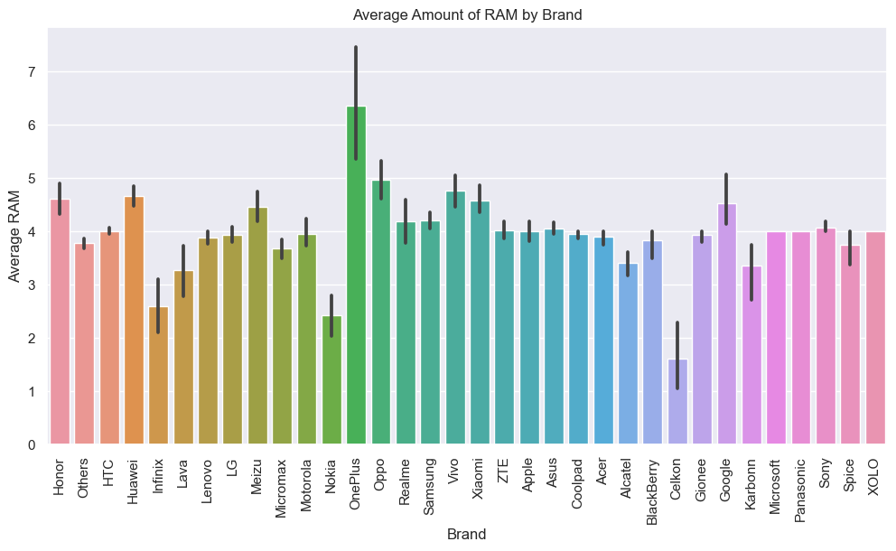

```python
# Create a barplot of average RAM by brand
fig, ax = plt.subplots(figsize=(12, 6))
sns.barplot(data=df, x='brand_name', y='ram', ax=ax)

# Set plot labels and title
ax.set_xlabel('Brand')
ax.set_ylabel('Average RAM')
ax.set_title('Average Amount of RAM by Brand')

plt.xticks(rotation=90)  # Rotate x-axis labels if needed

plt.show()
```

##### 4. A large battery often increases a device's weight, making it feel uncomfortable in the hands. How does the weight vary for phones and tablets offering large batteries (more than 4500 mAh)?

- Plot shows amount of RAM vary with the brand. Oneplus having the highest RAM size.

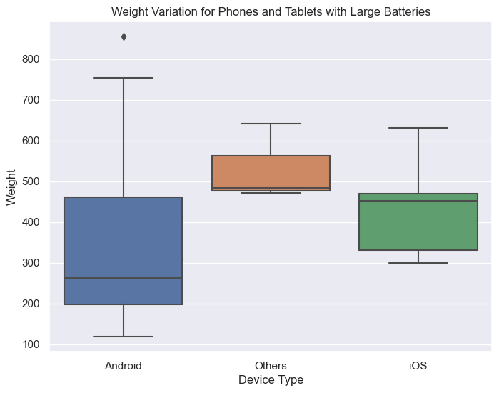

```python
# Filter the DataFrame to include only phones and tablets with large batteries
filtered_df = df[(df['battery'] > 4500) & (df['weight'].notna())]

# Create a boxplot to compare the weight distribution
fig, ax = plt.subplots(figsize=(8, 6))
sns.boxplot(data=filtered_df, x='os', y='weight', ax=ax)

# Set plot labels and title
ax.set_xlabel('Device Type')
ax.set_ylabel('Weight')
ax.set_title('Weight Variation for Phones and Tablets with Large Batteries')

plt.show()
```

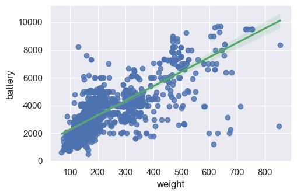

```python
filtered_df = df[(df['battery'] > 4500) & (df['weight'].notna())]
# fig, ax = plt.subplots(figsize=(8, 6))
sns.lmplot(data=df, x='weight', y='battery', line_kws={'color': 'g'}, height=3.5, aspect=1.5)
plt.show()
```

- Weight has positive corelation with battery - as battery capacity increases weight increases.

##### 5. Bigger screens are desirable for entertainment purposes as they offer a better viewing experience. How many phones and tablets are available across different brands with a screen size larger than 6 inches?

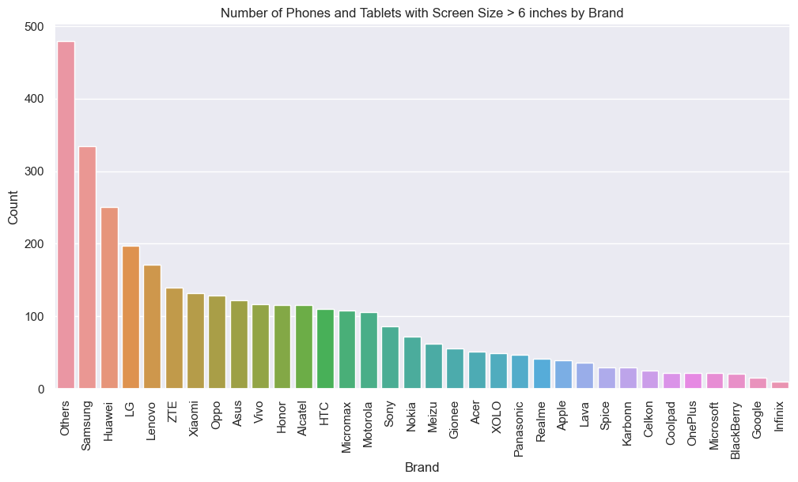

```python
df=data.copy()
filtered_df = df[df['screen_size'] > 6]

# Count the number of phones and tablets for each brand
counts = filtered_df['brand_name'].value_counts().reset_index()

# Create a barplot to visualize the counts
fig, ax = plt.subplots(figsize=(12, 6))
sns.barplot(data=counts, x='index', y='brand_name', ax=ax)

# Set plot labels and title
ax.set_xlabel('Brand')
ax.set_ylabel('Count')
ax.set_title('Number of Phones and Tablets with Screen Size > 6 inches by Brand')

plt.xticks(rotation=90)  # Rotate x-axis labels if needed

plt.show()
```

##### 6. A lot of devices nowadays offer great selfie cameras, allowing us to capture our favorite moments with loved ones. What is the distribution of devices offering greater than 8MP selfie cameras across brands?

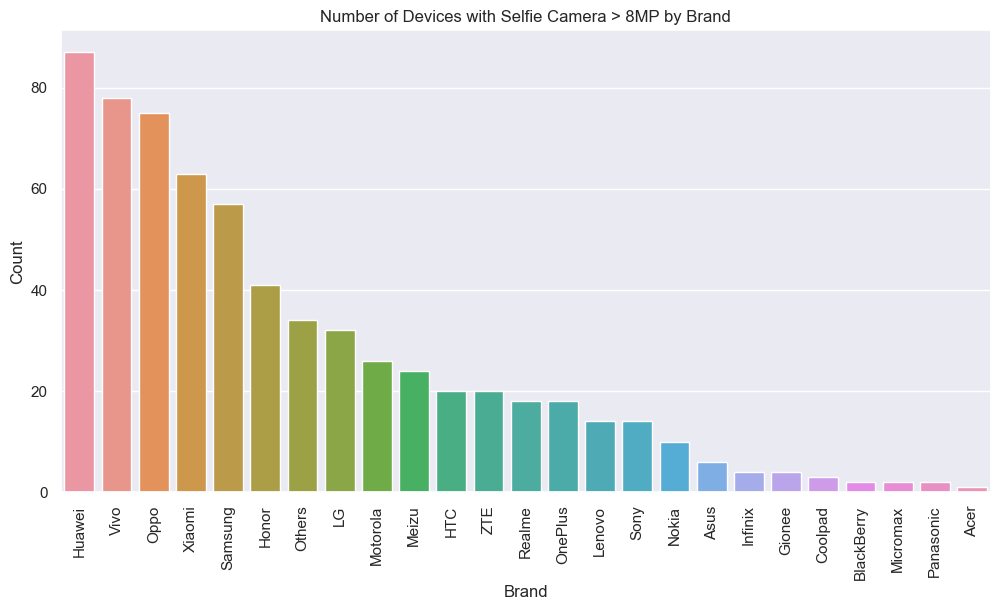

```python
df=data.copy()
filtered_df = df[df['selfie_camera_mp'] > 8]

# Count the number of devices for each brand
counts = filtered_df['brand_name'].value_counts().reset_index()

# Create a barplot to visualize the counts
fig, ax = plt.subplots(figsize=(12, 6))
sns.barplot(data=counts, x='index', y='brand_name', ax=ax)

# Set plot labels and title
ax.set_xlabel('Brand')
ax.set_ylabel('Count')
ax.set_title('Number of Devices with Selfie Camera > 8MP by Brand')

plt.xticks(rotation=90)  # Rotate x-axis labels if needed

plt.show()
```

- Distribution of devices offering greater than 8MP selfie cameras across brands. Out of all the distribution - Huawei provides selfie camera with good MP.

##### 7. Which attributes are highly correlated with the normalized price of a used device?

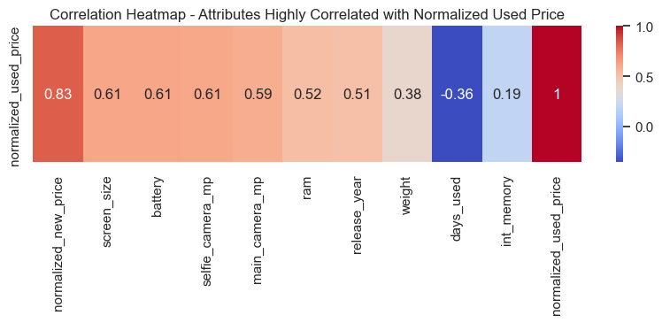

```python
# Calculate the correlation matrix
correlation_matrix = df.corr()

# Filter the correlation matrix to include only the correlation with the normalized used price
correlation_with_price = correlation_matrix['normalized_used_price'].drop('normalized_used_price')

# Sort the correlations in descending order
sorted_correlations = correlation_with_price.abs().sort_values(ascending=False)

# Select the top correlated attributes
top_correlated_attributes = sorted_correlations[:12].index.tolist()

# Create a subset DataFrame with the top correlated attributes and the normalized used price
subset_df = df[top_correlated_attributes + ['normalized_used_price']]

# Calculate the correlation matrix for the subset DataFrame
subset_correlation_matrix = subset_df.corr()

# Create a heatmap of the correlation matrix
plt.figure(figsize=(10, 2))
sns.heatmap(subset_correlation_matrix[-1:], annot=True, cmap='coolwarm')

plt.title('Correlation Heatmap - Attributes Highly Correlated with Normalized Used Price')

plt.show()
```

```python
subset_correlation_matrix
```

|  | normalized_new_price | screen_size | battery | selfie_camera_mp | main_camera_mp | ram | release_year | weight | days_used | int_memory | normalized_used_price |
| --- | --- | --- | --- | --- | --- | --- | --- | --- | --- | --- | --- |
| normalized_new_price | 1.000000 | 0.460889 | 0.470754 | 0.475479 | 0.541655 | 0.532056 | 0.303689 | 0.269540 | -0.216625 | 0.195992 | 0.834496 |
| screen_size | 0.460889 | 1.000000 | 0.813533 | 0.271640 | 0.150316 | 0.274449 | 0.364223 | 0.828890 | -0.291723 | 0.071291 | 0.614785 |
| battery | 0.470754 | 0.813533 | 1.000000 | 0.369709 | 0.248563 | 0.280740 | 0.488660 | 0.703388 | -0.370895 | 0.117736 | 0.613619 |
| selfie_camera_mp | 0.475479 | 0.271640 | 0.369709 | 1.000000 | 0.429264 | 0.477411 | 0.690942 | -0.004997 | -0.552636 | 0.296426 | 0.608074 |
| main_camera_mp | 0.541655 | 0.150316 | 0.248563 | 0.429264 | 1.000000 | 0.260802 | 0.353728 | -0.087738 | -0.144672 | 0.018766 | 0.587302 |
| ram | 0.532056 | 0.274449 | 0.280740 | 0.477411 | 0.260802 | 1.000000 | 0.314203 | 0.089916 | -0.280066 | 0.122496 | 0.520289 |
| release_year | 0.303689 | 0.364223 | 0.488660 | 0.690942 | 0.353728 | 0.314203 | 1.000000 | 0.071290 | -0.750390 | 0.235429 | 0.509790 |
| weight | 0.269540 | 0.828890 | 0.703388 | -0.004997 | -0.087738 | 0.089916 | 0.071290 | 1.000000 | -0.067470 | 0.014948 | 0.382354 |
| days_used | -0.216625 | -0.291723 | -0.370895 | -0.552636 | -0.144672 | -0.280066 | -0.750390 | -0.067470 | 1.000000 | -0.242712 | -0.358264 |
| int_memory | 0.195992 | 0.071291 | 0.117736 | 0.296426 | 0.018766 | 0.122496 | 0.235429 | 0.014948 | -0.242712 | 1.000000 | 0.190993 |
| normalized_used_price | 0.834496 | 0.614785 | 0.613619 | 0.608074 | 0.587302 | 0.520289 | 0.509790 | 0.382354 | -0.358264 | 0.190993 | 1.000000 |

- screen_size, battery, selfie_camera_mp, main_camera_mp have good correalation with normalized_used_price.

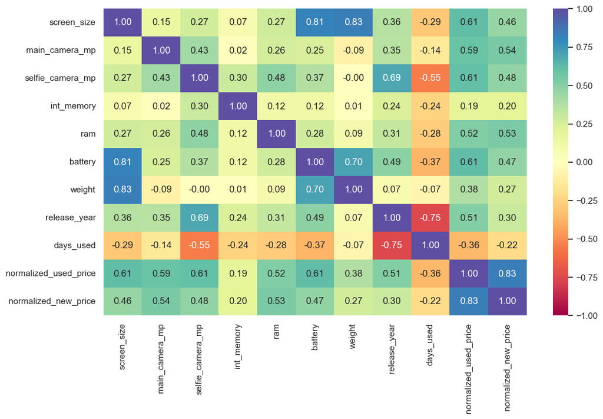

```python
plt.figure(figsize=(12, 7))
sns.heatmap(
    data.corr(), annot=True, vmin=-1, vmax=1, fmt=".2f", cmap="Spectral"
)
plt.show()
```

- Complete correlation matrix.

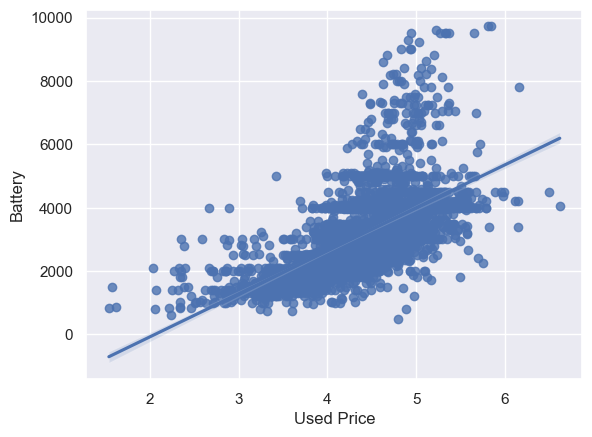

```python
sns.regplot(
    x='normalized_used_price',
    y='battery',
    data=data);
plt.xlabel(
    'Used Price')
plt.ylabel(
    'Battery');
plt.show()
```

- normalized_used_price and battery have positive linear plot.

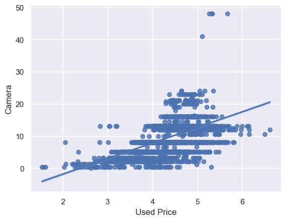

```python
sns.regplot(
    x='normalized_used_price',
    y='main_camera_mp',
    data=data);
plt.xlabel(
    'Used Price')
plt.ylabel(
    'Camera');
plt.show()
```

- normalized_used_price and camera have positive liner plot.

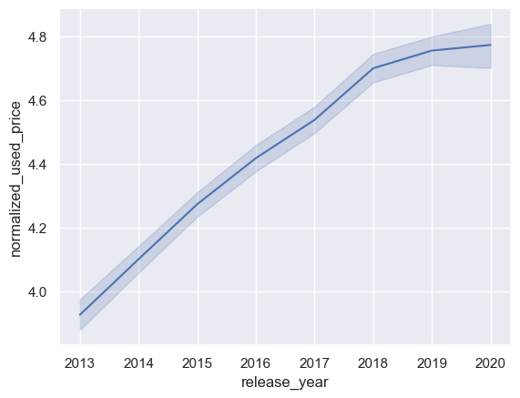

```python
sns.lineplot(
    x="release_year",
    y="normalized_used_price",
    data=data)
plt.show()
```

- Release_year and normalized_used_price have positive linear line plot.

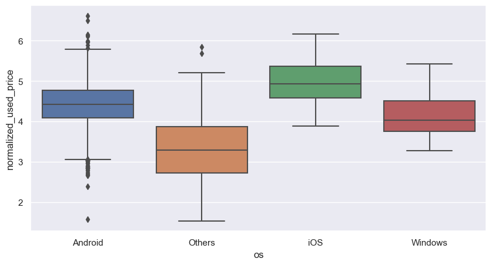

```python
plt.figure(figsize=(10, 5))
sns.boxplot(data=data, x="os", y="normalized_used_price")
plt.show()
```

- Boxplot for os and normalized_used_price shows that there are some outliers for Android and Others OS.

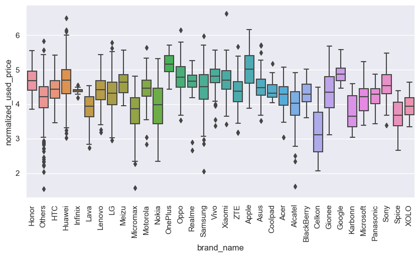

```python
plt.figure(figsize=(10, 5))
sns.boxplot(data=data, x="brand_name", y="normalized_used_price")
plt.xticks(rotation=90)
plt.show()
```

- Others have more number of outliers for normalized_used_price. Average normalized_used_price for OnePlus is higher compared to other brands

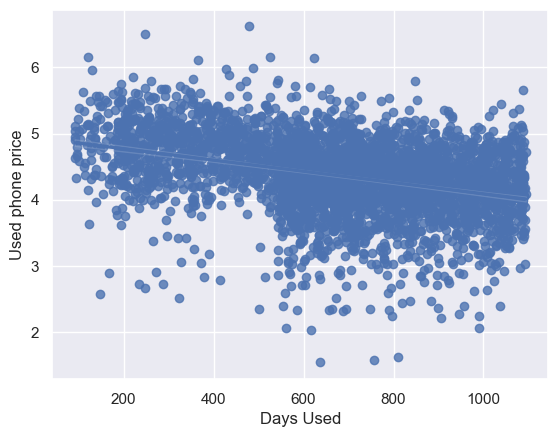

```python
sns.regplot(
    x='days_used',
    y='normalized_used_price',
    data=data);
plt.xlabel(
    'Days Used')
plt.ylabel(
    'Used phone price');
plt.show()
```

Days used and normalized_used_price have negative linear plot. With less days used phone having higher cost.

## Data Preprocessing

- Missing value treatment
- Feature engineering (if needed)
- Outlier detection and treatment (if needed)
- Preparing data for modeling
- Any other preprocessing steps (if needed)

```python
data.isnull().sum()
```

```
brand_name                 0
os                         0
screen_size                0
4g                         0
5g                         0
main_camera_mp           179
selfie_camera_mp           2
int_memory                 4
ram                        4
battery                    6
weight                     7
release_year               0
days_used                  0
normalized_used_price      0
normalized_new_price       0
dtype: int64
```

# Filling in the missing values with median values.

```python
data["main_camera_mp"]=data["main_camera_mp"].fillna(data["main_camera_mp"].median())
```

```python
data["selfie_camera_mp"]=data["selfie_camera_mp"].fillna(data["selfie_camera_mp"].median())
```

```python
data["int_memory"]=data["int_memory"].fillna(data["int_memory"].median())
```

```python
data["ram"]=data["ram"].fillna(data["ram"].median())
```

```python
data["battery"]=data["battery"].fillna(data["battery"].median())
```

```python
data["weight"]=data["weight"].fillna(data["weight"].median())
```

```python
data.isnull().sum()
```

```
brand_name               0
os                       0
screen_size              0
4g                       0
5g                       0
main_camera_mp           0
selfie_camera_mp         0
int_memory               0
ram                      0
battery                  0
weight                   0
release_year             0
days_used                0
normalized_used_price    0
normalized_new_price     0
dtype: int64
```

- No missing values after after replacing the null values with median values.

## EDA

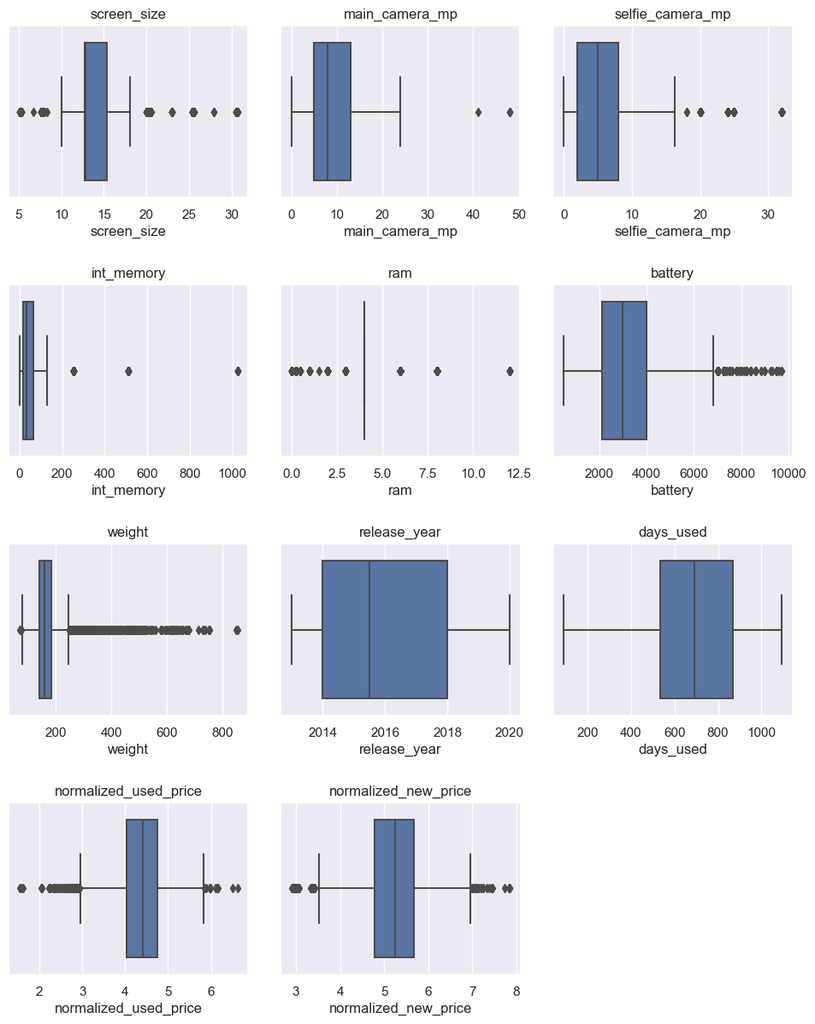

```python
num_cols = data.select_dtypes(include=np.number).columns.tolist()

num_plots = min(len(num_cols), 15)  # Maximum of 9 plots

plt.figure(figsize=(10, 15))
for i in range(num_plots):
    plt.subplot(5, 3, i+1)
    sns.boxplot(data=data, x=num_cols[i])
    plt.title(num_cols[i])  # Set the subplot title as the column name
    plt.tight_layout(pad=2)

plt.show()
```

- There are quite a few outliers in the data
- However, we will not treat them as they are actual values which we need for our linear regresssion

```python
df=data.copy()
```

# Featured Engineering

##### * As per the industry standards the biggest phone available in market today is about 17.27 cms and we are considering the data with any device with screen_size more than 17.27 cms are Tablet and anything less and 17.27 cms is a Phone.

```python
df['device_type'] = np.where(df['screen_size']>17.27,'Tablet','Phone')
df
```

|  | brand_name | os | screen_size | 4g | 5g | main_camera_mp | selfie_camera_mp | int_memory | ram | battery | weight | release_year | days_used | normalized_used_price | normalized_new_price | device_type |
| --- | --- | --- | --- | --- | --- | --- | --- | --- | --- | --- | --- | --- | --- | --- | --- | --- |
| 0 | Honor | Android | 14.50 | yes | no | 13.0 | 5.0 | 64.0 | 3.0 | 3020.0 | 146.0 | 2020 | 127 | 4.307572 | 4.715100 | Phone |
| 1 | Honor | Android | 17.30 | yes | yes | 13.0 | 16.0 | 128.0 | 8.0 | 4300.0 | 213.0 | 2020 | 325 | 5.162097 | 5.519018 | Tablet |
| 2 | Honor | Android | 16.69 | yes | yes | 13.0 | 8.0 | 128.0 | 8.0 | 4200.0 | 213.0 | 2020 | 162 | 5.111084 | 5.884631 | Phone |
| 3 | Honor | Android | 25.50 | yes | yes | 13.0 | 8.0 | 64.0 | 6.0 | 7250.0 | 480.0 | 2020 | 345 | 5.135387 | 5.630961 | Tablet |
| 4 | Honor | Android | 15.32 | yes | no | 13.0 | 8.0 | 64.0 | 3.0 | 5000.0 | 185.0 | 2020 | 293 | 4.389995 | 4.947837 | Phone |
| ... | ... | ... | ... | ... | ... | ... | ... | ... | ... | ... | ... | ... | ... | ... | ... | ... |
| 3449 | Asus | Android | 15.34 | yes | no | 8.0 | 8.0 | 64.0 | 6.0 | 5000.0 | 190.0 | 2019 | 232 | 4.492337 | 6.483872 | Phone |
| 3450 | Asus | Android | 15.24 | yes | no | 13.0 | 8.0 | 128.0 | 8.0 | 4000.0 | 200.0 | 2018 | 541 | 5.037732 | 6.251538 | Phone |
| 3451 | Alcatel | Android | 15.80 | yes | no | 13.0 | 5.0 | 32.0 | 3.0 | 4000.0 | 165.0 | 2020 | 201 | 4.357350 | 4.528829 | Phone |
| 3452 | Alcatel | Android | 15.80 | yes | no | 13.0 | 5.0 | 32.0 | 2.0 | 4000.0 | 160.0 | 2020 | 149 | 4.349762 | 4.624188 | Phone |
| 3453 | Alcatel | Android | 12.83 | yes | no | 13.0 | 5.0 | 16.0 | 2.0 | 4000.0 | 168.0 | 2020 | 176 | 4.132122 | 4.279994 | Phone |

3454 rows × 16 columns

```python
df_phone=df[df['device_type']=="Phone"]
df_phone.dtypes
```

```
brand_name                object
os                        object
screen_size              float64
4g                        object
5g                        object
main_camera_mp           float64
selfie_camera_mp         float64
int_memory               float64
ram                      float64
battery                  float64
weight                   float64
release_year               int64
days_used                  int64
normalized_used_price    float64
normalized_new_price     float64
device_type               object
dtype: object
```

```python
df_tablet=df[df['device_type']=="Tablet"]
df_tablet
```

|  | brand_name | os | screen_size | 4g | 5g | main_camera_mp | selfie_camera_mp | int_memory | ram | battery | weight | release_year | days_used | normalized_used_price | normalized_new_price | device_type |
| --- | --- | --- | --- | --- | --- | --- | --- | --- | --- | --- | --- | --- | --- | --- | --- | --- |
| 1 | Honor | Android | 17.30 | yes | yes | 13.0 | 16.0 | 128.0 | 8.0 | 4300.0 | 213.0 | 2020 | 325 | 5.162097 | 5.519018 | Tablet |
| 3 | Honor | Android | 25.50 | yes | yes | 13.0 | 8.0 | 64.0 | 6.0 | 7250.0 | 480.0 | 2020 | 345 | 5.135387 | 5.630961 | Tablet |
| 19 | Honor | Android | 25.43 | yes | no | 5.0 | 2.0 | 32.0 | 3.0 | 5100.0 | 173.0 | 2019 | 266 | 4.267878 | 5.517051 | Tablet |
| 20 | Honor | Android | 20.32 | yes | no | 8.0 | 8.0 | 32.0 | 3.0 | 5100.0 | 173.0 | 2019 | 321 | 4.556295 | 5.304001 | Tablet |
| 21 | Others | Android | 20.32 | no | no | 8.0 | 0.3 | 16.0 | 1.0 | 5680.0 | 453.6 | 2013 | 933 | 4.452136 | 5.484382 | Tablet |
| ... | ... | ... | ... | ... | ... | ... | ... | ... | ... | ... | ... | ... | ... | ... | ... | ... |
| 3216 | Huawei | Android | 17.83 | yes | yes | 13.0 | 24.0 | 256.0 | 8.0 | 4200.0 | 233.0 | 2019 | 279 | 5.156984 | 6.191851 | Tablet |
| 3304 | Xiaomi | Android | 17.81 | yes | yes | 8.0 | 20.0 | 256.0 | 8.0 | 5000.0 | 253.0 | 2020 | 361 | 5.223917 | 6.509499 | Tablet |
| 3348 | Huawei | Android | 20.32 | yes | yes | 10.5 | 16.0 | 512.0 | 8.0 | 4500.0 | 300.0 | 2020 | 129 | 5.959251 | 7.847841 | Tablet |
| 3357 | Huawei | Android | 17.83 | yes | yes | 13.0 | 24.0 | 256.0 | 8.0 | 4200.0 | 233.0 | 2019 | 351 | 5.299367 | 6.191851 | Tablet |
| 3436 | Samsung | Android | 17.86 | yes | yes | 12.0 | 9.0 | 512.0 | 12.0 | 4235.0 | 263.0 | 2019 | 434 | 5.573750 | 7.333016 | Tablet |

402 rows × 16 columns

```python
df_phone.shape
```

```
(3052, 16)
```

- There are 3052 Phone devices in the dataset.

```python
df_tablet.shape
```

```
(402, 16)
```

- There are 402 Tablet devices in the dataset.

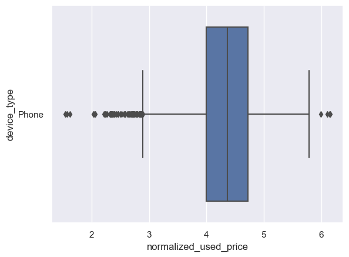

```python
sns.boxplot(data=df_phone, x="normalized_used_price", y="device_type")
plt.show()
```

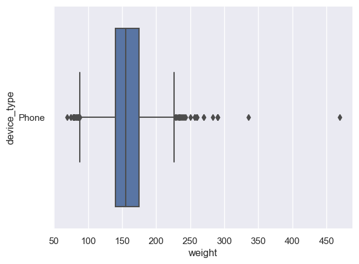

```python
sns.boxplot(data=df_phone, x="weight", y="device_type")
plt.show()
```

### Data Preparation for Modeling

- We want to predict the normalized_used_price of an used phone.
- Before we proceed to build a model, we'll have to encode categorical features
- We'll split the data into train and test to be able to evaluate the model that we build on the train data
- We will build a Linear Regression model using the train data and then check it's performance

```python
X= df_phone.drop(["normalized_used_price"],axis=1)
y= df_phone["normalized_used_price"]
print(X.head())
print(y.head())
```

```
  brand_name       os  screen_size   4g   5g  main_camera_mp  \
0      Honor  Android        14.50  yes   no            13.0
2      Honor  Android        16.69  yes  yes            13.0
4      Honor  Android        15.32  yes   no            13.0
5      Honor  Android        16.23  yes   no            13.0
6      Honor  Android        13.84  yes   no             8.0

   selfie_camera_mp  int_memory  ram  battery  weight  release_year  \
0               5.0        64.0  3.0   3020.0   146.0          2020
2               8.0       128.0  8.0   4200.0   213.0          2020
4               8.0        64.0  3.0   5000.0   185.0          2020
5               8.0        64.0  4.0   4000.0   176.0          2020
6               5.0        32.0  2.0   3020.0   144.0          2020

   days_used  normalized_new_price device_type
0        127              4.715100       Phone
2        162              5.884631       Phone
4        293              4.947837       Phone
5        223              5.060694       Phone
6        234              4.518958       Phone
0    4.307572
2    5.111084
4    4.389995
5    4.413889
6    3.878259
Name: normalized_used_price, dtype: float64
```

```python
X = sm.add_constant(X)
```

```python
X.head()
```

|  | const | brand_name | os | screen_size | 4g | 5g | main_camera_mp | selfie_camera_mp | int_memory | ram | battery | weight | release_year | days_used | normalized_new_price | device_type |
| --- | --- | --- | --- | --- | --- | --- | --- | --- | --- | --- | --- | --- | --- | --- | --- | --- |
| 0 | 1.0 | Honor | Android | 14.50 | yes | no | 13.0 | 5.0 | 64.0 | 3.0 | 3020.0 | 146.0 | 2020 | 127 | 4.715100 | Phone |
| 2 | 1.0 | Honor | Android | 16.69 | yes | yes | 13.0 | 8.0 | 128.0 | 8.0 | 4200.0 | 213.0 | 2020 | 162 | 5.884631 | Phone |
| 4 | 1.0 | Honor | Android | 15.32 | yes | no | 13.0 | 8.0 | 64.0 | 3.0 | 5000.0 | 185.0 | 2020 | 293 | 4.947837 | Phone |
| 5 | 1.0 | Honor | Android | 16.23 | yes | no | 13.0 | 8.0 | 64.0 | 4.0 | 4000.0 | 176.0 | 2020 | 223 | 5.060694 | Phone |
| 6 | 1.0 | Honor | Android | 13.84 | yes | no | 8.0 | 5.0 | 32.0 | 2.0 | 3020.0 | 144.0 | 2020 | 234 | 4.518958 | Phone |

```python
# creating dummy variables
X = pd.get_dummies(
    X,
    columns=X.select_dtypes(include=["object", "category"]).columns.tolist(),
    drop_first=True,
)
X.head()
```

|  | const | screen_size | main_camera_mp | selfie_camera_mp | int_memory | ram | battery | weight | release_year | days_used | ... | brand_name_Spice | brand_name_Vivo | brand_name_XOLO | brand_name_Xiaomi | brand_name_ZTE | os_Others | os_Windows | os_iOS | 4g_yes | 5g_yes |
| --- | --- | --- | --- | --- | --- | --- | --- | --- | --- | --- | --- | --- | --- | --- | --- | --- | --- | --- | --- | --- | --- |
| 0 | 1.0 | 14.50 | 13.0 | 5.0 | 64.0 | 3.0 | 3020.0 | 146.0 | 2020 | 127 | ... | 0 | 0 | 0 | 0 | 0 | 0 | 0 | 0 | 1 | 0 |
| 2 | 1.0 | 16.69 | 13.0 | 8.0 | 128.0 | 8.0 | 4200.0 | 213.0 | 2020 | 162 | ... | 0 | 0 | 0 | 0 | 0 | 0 | 0 | 0 | 1 | 1 |
| 4 | 1.0 | 15.32 | 13.0 | 8.0 | 64.0 | 3.0 | 5000.0 | 185.0 | 2020 | 293 | ... | 0 | 0 | 0 | 0 | 0 | 0 | 0 | 0 | 1 | 0 |
| 5 | 1.0 | 16.23 | 13.0 | 8.0 | 64.0 | 4.0 | 4000.0 | 176.0 | 2020 | 223 | ... | 0 | 0 | 0 | 0 | 0 | 0 | 0 | 0 | 1 | 0 |
| 6 | 1.0 | 13.84 | 8.0 | 5.0 | 32.0 | 2.0 | 3020.0 | 144.0 | 2020 | 234 | ... | 0 | 0 | 0 | 0 | 0 | 0 | 0 | 0 | 1 | 0 |

5 rows × 49 columns

```python
x_train,x_test,y_train,y_test = train_test_split(X, y, test_size=0.3, random_state=1)
```

```python
print("Number of rows in train data =", x_train.shape[0])
print("Number of rows in test data =", x_test.shape[0])
```

```
Number of rows in train data = 2136
Number of rows in test data = 916
```

## Model Building - Linear Regression

```python
olsmodel = sm.OLS(y_train, x_train).fit()
print(olsmodel.summary())
```

```
                              OLS Regression Results
=================================================================================
Dep. Variable:     normalized_used_price   R-squared:                       0.843
Model:                               OLS   Adj. R-squared:                  0.839
Method:                    Least Squares   F-statistic:                     237.9
Date:                   Sun, 18 Jun 2023   Prob (F-statistic):               0.00
Time:                           23:30:44   Log-Likelihood:                 40.857
No. Observations:                   2136   AIC:                             14.29
Df Residuals:                       2088   BIC:                             286.3
Df Model:                             47
Covariance Type:               nonrobust
=========================================================================================
                            coef    std err          t      P>|t|      [0.025      0.975]
-----------------------------------------------------------------------------------------
const                   -59.2720     11.032     -5.373      0.000     -80.907     -37.637
screen_size               0.0349      0.005      7.469      0.000       0.026       0.044
main_camera_mp            0.0222      0.002     12.857      0.000       0.019       0.026
selfie_camera_mp          0.0115      0.001      9.415      0.000       0.009       0.014
int_memory             7.741e-05   7.24e-05      1.069      0.285   -6.46e-05       0.000
ram                       0.0148      0.006      2.551      0.011       0.003       0.026
battery               -5.169e-06   1.11e-05     -0.466      0.641   -2.69e-05    1.66e-05
weight                    0.0011      0.000      3.738      0.000       0.001       0.002
release_year              0.0299      0.005      5.466      0.000       0.019       0.041
days_used              9.962e-05    3.4e-05      2.931      0.003     3.3e-05       0.000
normalized_new_price      0.4288      0.013     32.029      0.000       0.403       0.455
brand_name_Alcatel       -0.0258      0.057     -0.454      0.650      -0.137       0.086
brand_name_Apple          0.0229      0.042      0.548      0.584      -0.059       0.105
brand_name_Asus           0.0565      0.059      0.956      0.339      -0.059       0.172
brand_name_BlackBerry     0.0867      0.078      1.117      0.264      -0.065       0.239
brand_name_Celkon        -0.0064      0.076     -0.085      0.932      -0.155       0.142
brand_name_Coolpad        0.0365      0.081      0.449      0.653      -0.123       0.196
brand_name_Gionee         0.0335      0.062      0.543      0.587      -0.087       0.154
brand_name_Google         0.0737      0.095      0.773      0.440      -0.113       0.261
brand_name_HTC            0.0040      0.057      0.071      0.943      -0.107       0.115
brand_name_Honor          0.0391      0.058      0.669      0.503      -0.075       0.154
brand_name_Huawei        -0.0086      0.054     -0.160      0.873      -0.115       0.097
brand_name_Infinix        0.1634      0.105      1.557      0.120      -0.042       0.369
brand_name_Karbonn        0.0522      0.072      0.728      0.466      -0.088       0.193
brand_name_LG             0.0045      0.054      0.084      0.933      -0.101       0.111
brand_name_Lava           0.0135      0.071      0.190      0.849      -0.126       0.153
```

[output cut: 19 more lines]

```
os_Windows                0.0072      0.046      0.156      0.876      -0.083       0.098
os_iOS                    0.0229      0.042      0.548      0.584      -0.059       0.105
4g_yes                    0.0371      0.019      2.005      0.045       0.001       0.073
5g_yes                    0.0108      0.034      0.314      0.754      -0.057       0.078
==============================================================================
Omnibus:                      208.973   Durbin-Watson:                   1.958
Prob(Omnibus):                  0.000   Jarque-Bera (JB):              537.000
Skew:                          -0.552   Prob(JB):                    2.47e-117
Kurtosis:                       5.194   Cond. No.                     1.02e+16
==============================================================================

Notes:
[1] Standard Errors assume that the covariance matrix of the errors is correctly specified.
[2] The smallest eigenvalue is 2.77e-22. This might indicate that there are
strong multicollinearity problems or that the design matrix is singular.
```

### Interpreting the Regression Results:

1. **Adjusted. R-squared**: It reflects the fit of the model.
   - Adjusted R-squared values generally range from 0 to 1, where a higher value generally indicates a better fit, assuming certain conditions are met.
   - In our case, the value for adj. R-squared is **0.839**, which is good.
1. *const* coefficient: It is the Y-intercept.
   - It means that if all the predictor variable coefficients are zero, then the expected output (i.e., Y) would be equal to the *const* coefficient.
   - In our case, the value for `const` coefficient is **-59.2720**
1. **Coefficient of a predictor variable**: It represents the change in the output Y due to a change in the predictor variable (everything else held constant).
   - In our case, the coefficient of `release_year` is **0.0299**.

## Model Performance Check

Let's check the performance of the model using different metrics.

- We will be using metric functions defined in sklearn for RMSE, MAE, and $R^2$.
- We will define a function to calculate MAPE and adjusted $R^2$.
  - The mean absolute percentage error (MAPE) measures the accuracy of predictions as a percentage, and can be calculated as the average absolute percent error for each predicted value minus actual values divided by actual values. It works best if there are no extreme values in the data and none of the actual values are 0.
- We will create a function which will print out all the above metrics in one go.

```python
# function to compute adjusted R-squared
def adj_r2_score(predictors, targets, predictions):
    r2 = r2_score(targets, predictions)
    n = predictors.shape[0]
    k = predictors.shape[1]
    return 1 - ((1 - r2) * (n - 1) / (n - k - 1))


# function to compute MAPE
def mape_score(targets, predictions):
    return np.mean(np.abs(targets - predictions) / targets) * 100


# function to compute different metrics to check performance of a regression model
def model_performance_regression(model, predictors, target):
    """
    Function to compute different metrics to check regression model performance

    model: regressor
    predictors: independent variables
    target: dependent variable
    """

    # predicting using the independent variables
    pred = model.predict(predictors)

    r2 = r2_score(target, pred)  # to compute R-squared
    adjr2 = adj_r2_score(predictors, target, pred)  # to compute adjusted R-squared
    rmse = np.sqrt(mean_squared_error(target, pred))  # to compute RMSE
    mae = mean_absolute_error(target, pred)  # to compute MAE
    mape = mape_score(target, pred)  # to compute MAPE

    # creating a dataframe of metrics
    df_perf = pd.DataFrame(
        {
            "RMSE": rmse,
            "MAE": mae,
            "R-squared": r2,
            "Adj. R-squared": adjr2,
            "MAPE": mape,
        },
        index=[0],
    )

    return df_perf
```

```python
# checking model performance on train set (seen 70% data)
print("Training Performance\n")
olsmodel_train_perf = model_performance_regression(olsmodel, x_train, y_train)
olsmodel_train_perf
```

```
Training Performance
```

|  | RMSE | MAE | R-squared | Adj. R-squared | MAPE |
| --- | --- | --- | --- | --- | --- |
| 0 | 0.237386 | 0.183602 | 0.842632 | 0.838936 | 4.481238 |

```python
print("Test Performance\n")
olsmodel_test_perf = model_performance_regression(olsmodel, x_test, y_test)
olsmodel_test_perf
```

```
Test Performance
```

|  | RMSE | MAE | R-squared | Adj. R-squared | MAPE |
| --- | --- | --- | --- | --- | --- |
| 0 | 0.221736 | 0.176935 | 0.855745 | 0.847582 | 4.226534 |

**Observations**

- The training $R^2$ is 0.843, so the model is not underfitting
- The train and test RMSE and MAE are comparable, so the model is not overfitting either
- MAE suggests that the model can predict normalized_used_price within a mean error of 00.17 on the test data
- MAPE of 4.227 on the test data means that we are able to predict within 4.27% of the normalized_used_price for phone devices.

## Checking Linear Regression Assumptions

We will be checking the following Linear Regression assumptions:

1. **No Multicollinearity**
2. **Linearity of variables**
3. **Independence of error terms**
4. **Normality of error terms**
5. **No Heteroscedasticity**

### TEST FOR MULTICOLLINEARITY

Multicollinearity occurs when predictor variables in a regression model are correlated. This correlation is a problem because predictor variables should be independent. If the correlation between variables is high, it can cause problems when we fit the model and interpret the results. When we have multicollinearity in the linear model, the coefficients that the model suggests are unreliable.

There are different ways of detecting (or testing) multicollinearity. One such way is by using the Variance Inflation Factor, or VIF.

Variance Inflation Factor (VIF): Variance inflation factors measure the inflation in the variances of the regression parameter estimates due to collinearities that exist among the predictors. It is a measure of how much the variance of the estimated regression coefficient 𝛽𝑘 is "inflated" by the existence of correlation among the predictor variables in the model.

If VIF is 1, then there is no correlation among the 𝑘 th predictor and the remaining predictor variables, and hence, the variance of 𝛽𝑘 is not inflated at all. General Rule of thumb:

If VIF is between 1 and 5, then there is low multicollinearity. If VIF is between 5 and 10, we say there is moderate multicollinearity. If VIF is exceeding 10, it shows signs of high multicollinearity.

Let's define a function to check VIF.

```python
from statsmodels.stats.outliers_influence import variance_inflation_factor


def checking_vif(predictors):
    vif = pd.DataFrame()
    vif["feature"] = predictors.columns

    # calculating VIF for each feature
    vif["VIF"] = [
        variance_inflation_factor(predictors.values, i)
        for i in range(len(predictors.columns))
    ]
    return vif
```

```python
pd.set_option('display.float_format', lambda x: '%.3f' % x)
```

```python
checking_vif(x_train)
```

|  | feature | VIF |
| --- | --- | --- |
| 0 | const | 4509664.474 |
| 1 | screen_size | 5.228 |
| 2 | main_camera_mp | 2.290 |
| 3 | selfie_camera_mp | 2.834 |
| 4 | int_memory | 1.272 |
| 5 | ram | 2.299 |
| 6 | battery | 4.488 |
| 7 | weight | 2.711 |
| 8 | release_year | 5.765 |
| 9 | days_used | 2.659 |
| 10 | normalized_new_price | 3.161 |
| 11 | brand_name_Alcatel | 3.940 |
| 12 | brand_name_Apple | inf |
| 13 | brand_name_Asus | 3.303 |
| 14 | brand_name_BlackBerry | 1.862 |
| 15 | brand_name_Celkon | 1.972 |
| 16 | brand_name_Coolpad | 1.592 |
| 17 | brand_name_Gionee | 2.772 |
| 18 | brand_name_Google | 1.414 |
| 19 | brand_name_HTC | 4.078 |
| 20 | brand_name_Honor | 3.786 |
| 21 | brand_name_Huawei | 6.353 |
| 22 | brand_name_Infinix | 1.333 |
| 23 | brand_name_Karbonn | 1.938 |
| 24 | brand_name_LG | 5.826 |
| 25 | brand_name_Lava | 1.985 |
| 26 | brand_name_Lenovo | 4.643 |
| 27 | brand_name_Meizu | 2.806 |
| 28 | brand_name_Micromax | 4.020 |
| 29 | brand_name_Microsoft | 1.941 |
| 30 | brand_name_Motorola | 3.998 |
| 31 | brand_name_Nokia | 4.125 |
| 32 | brand_name_OnePlus | 1.718 |
| 33 | brand_name_Oppo | 4.940 |
| 34 | brand_name_Others | 11.743 |
| 35 | brand_name_Panasonic | 2.356 |
| 36 | brand_name_Realme | 2.531 |
| 37 | brand_name_Samsung | 8.506 |
| 38 | brand_name_Sony | 3.501 |
| 39 | brand_name_Spice | 1.867 |
| 40 | brand_name_Vivo | 4.682 |
| 41 | brand_name_XOLO | 2.324 |
| 42 | brand_name_Xiaomi | 4.531 |
| 43 | brand_name_ZTE | 4.771 |
| 44 | os_Others | 2.025 |
| 45 | os_Windows | 1.587 |
| 46 | os_iOS | inf |
| 47 | 4g_yes | 2.653 |
| 48 | 5g_yes | 1.832 |

- There are multiple columns with very high VIF values, indicating presence of strong multicollinearity
- We will systematically drop numerical columns with VIF > 5
- We will ignore the VIF values for dummy variables and the constant (intercept)

### Removing Multicollinearity

To remove multicollinearity

1. Drop every column one by one that has a VIF score greater than 5.
2. Look at the adjusted R-squared and RMSE of all these models.
3. Drop the variable that makes the least change in adjusted R-squared.
4. Check the VIF scores again.
5. Continue till you get all VIF scores under 5.

Let's define a function that will help us do this.

```python
def treating_multicollinearity(predictors, target, high_vif_columns):
    """
    Checking the effect of dropping the columns showing high multicollinearity
    on model performance (adj. R-squared and RMSE)

    predictors: independent variables
    target: dependent variable
    high_vif_columns: columns having high VIF
    """
    # empty lists to store adj. R-squared and RMSE values
    adj_r2 = []
    rmse = []

    # build ols models by dropping one of the high VIF columns at a time
    # store the adjusted R-squared and RMSE in the lists defined previously
    for cols in high_vif_columns:
        # defining the new train set
        train = predictors.loc[:, ~predictors.columns.str.startswith(cols)]

        # create the model
        olsmodel = sm.OLS(target, train).fit()

        # adding adj. R-squared and RMSE to the lists
        adj_r2.append(olsmodel.rsquared_adj)
        rmse.append(np.sqrt(olsmodel.mse_resid))

    # creating a dataframe for the results
    temp = pd.DataFrame(
        {
            "col": high_vif_columns,
            "Adj. R-squared after_dropping col": adj_r2,
            "RMSE after dropping col": rmse,
        }
    ).sort_values(by="Adj. R-squared after_dropping col", ascending=False)
    temp.reset_index(drop=True, inplace=True)

    return temp
```

```python
col_list = ["screen_size", "release_year"]

res = treating_multicollinearity(x_train, y_train, col_list)
res
```

|  | col | Adj. R-squared after_dropping col | RMSE after dropping col |
| --- | --- | --- | --- |
| 0 | release_year | 0.837 | 0.242 |
| 1 | screen_size | 0.835 | 0.243 |

```python
col_to_drop = "release_year"
x_train1 = x_train.loc[:, ~x_train.columns.str.startswith(col_to_drop)]
x_test1 = x_test.loc[:, ~x_test.columns.str.startswith(col_to_drop)]

# Check VIF now
vif = checking_vif(x_train1)
print("VIF after dropping ", col_to_drop)
vif
```

```
VIF after dropping  release_year
```

|  | feature | VIF |
| --- | --- | --- |
| 0 | const | 267.871 |
| 1 | screen_size | 4.901 |
| 2 | main_camera_mp | 2.279 |
| 3 | selfie_camera_mp | 2.582 |
| 4 | int_memory | 1.266 |
| 5 | ram | 2.293 |
| 6 | battery | 4.217 |
| 7 | weight | 2.711 |
| 8 | days_used | 2.062 |
| 9 | normalized_new_price | 2.900 |
| 10 | brand_name_Alcatel | 3.940 |
| 11 | brand_name_Apple | inf |
| 12 | brand_name_Asus | 3.303 |
| 13 | brand_name_BlackBerry | 1.861 |
| 14 | brand_name_Celkon | 1.964 |
| 15 | brand_name_Coolpad | 1.592 |
| 16 | brand_name_Gionee | 2.772 |
| 17 | brand_name_Google | 1.399 |
| 18 | brand_name_HTC | 4.077 |
| 19 | brand_name_Honor | 3.784 |
| 20 | brand_name_Huawei | 6.351 |
| 21 | brand_name_Infinix | 1.333 |
| 22 | brand_name_Karbonn | 1.936 |
| 23 | brand_name_LG | 5.824 |
| 24 | brand_name_Lava | 1.985 |
| 25 | brand_name_Lenovo | 4.642 |
| 26 | brand_name_Meizu | 2.801 |
| 27 | brand_name_Micromax | 4.020 |
| 28 | brand_name_Microsoft | 1.932 |
| 29 | brand_name_Motorola | 3.994 |
| 30 | brand_name_Nokia | 4.082 |
| 31 | brand_name_OnePlus | 1.716 |
| 32 | brand_name_Oppo | 4.940 |
| 33 | brand_name_Others | 11.734 |
| 34 | brand_name_Panasonic | 2.355 |
| 35 | brand_name_Realme | 2.529 |
| 36 | brand_name_Samsung | 8.501 |
| 37 | brand_name_Sony | 3.499 |
| 38 | brand_name_Spice | 1.864 |
| 39 | brand_name_Vivo | 4.682 |
| 40 | brand_name_XOLO | 2.323 |
| 41 | brand_name_Xiaomi | 4.531 |
| 42 | brand_name_ZTE | 4.771 |
| 43 | os_Others | 2.019 |
| 44 | os_Windows | 1.573 |
| 45 | os_iOS | inf |
| 46 | 4g_yes | 2.311 |
| 47 | 5g_yes | 1.807 |

```python
olsmod1 = sm.OLS(y_train, x_train1).fit()
print(olsmod1.summary())
```

```
                              OLS Regression Results
=================================================================================
Dep. Variable:     normalized_used_price   R-squared:                       0.840
Model:                               OLS   Adj. R-squared:                  0.837
Method:                    Least Squares   F-statistic:                     239.1
Date:                   Sun, 18 Jun 2023   Prob (F-statistic):               0.00
Time:                           23:30:50   Log-Likelihood:                 25.684
No. Observations:                   2136   AIC:                             42.63
Df Residuals:                       2089   BIC:                             309.0
Df Model:                             46
Covariance Type:               nonrobust
=========================================================================================
                            coef    std err          t      P>|t|      [0.025      0.975]
-----------------------------------------------------------------------------------------
const                     1.0270      0.086     11.997      0.000       0.859       1.195
screen_size               0.0413      0.005      9.066      0.000       0.032       0.050
main_camera_mp            0.0215      0.002     12.419      0.000       0.018       0.025
selfie_camera_mp          0.0135      0.001     11.494      0.000       0.011       0.016
int_memory                0.0001   7.28e-05      1.419      0.156   -3.94e-05       0.000
ram                       0.0132      0.006      2.271      0.023       0.002       0.025
battery                9.729e-06   1.08e-05      0.899      0.369   -1.15e-05     3.1e-05
weight                    0.0011      0.000      3.685      0.000       0.001       0.002
days_used              1.159e-05   3.01e-05      0.384      0.701   -4.75e-05    7.07e-05
normalized_new_price      0.4078      0.013     31.583      0.000       0.382       0.433
brand_name_Alcatel       -0.0223      0.057     -0.390      0.697      -0.134       0.090
brand_name_Apple          0.0481      0.042      1.151      0.250      -0.034       0.130
brand_name_Asus           0.0582      0.059      0.978      0.328      -0.058       0.175
brand_name_BlackBerry     0.0775      0.078      0.993      0.321      -0.076       0.231
brand_name_Celkon        -0.0325      0.076     -0.426      0.670      -0.182       0.117
brand_name_Coolpad        0.0472      0.082      0.577      0.564      -0.113       0.208
brand_name_Gionee         0.0294      0.062      0.475      0.635      -0.092       0.151
brand_name_Google         0.1272      0.096      1.332      0.183      -0.060       0.315
brand_name_HTC            0.0056      0.057      0.098      0.922      -0.106       0.117
brand_name_Honor          0.0470      0.059      0.799      0.425      -0.068       0.162
brand_name_Huawei        -0.0032      0.054     -0.058      0.953      -0.110       0.103
brand_name_Infinix        0.1656      0.106      1.568      0.117      -0.042       0.373
brand_name_Karbonn        0.0390      0.072      0.541      0.588      -0.102       0.180
brand_name_LG             0.0094      0.054      0.173      0.862      -0.097       0.116
brand_name_Lava           0.0081      0.071      0.114      0.909      -0.132       0.148
brand_name_Lenovo         0.0294      0.056      0.526      0.599      -0.080       0.139
```

[output cut: 18 more lines]

```
os_Windows               -0.0161      0.046     -0.348      0.728      -0.107       0.075
os_iOS                    0.0481      0.042      1.151      0.250      -0.034       0.130
4g_yes                    0.0734      0.017      4.222      0.000       0.039       0.108
5g_yes                    0.0324      0.034      0.940      0.348      -0.035       0.100
==============================================================================
Omnibus:                      197.727   Durbin-Watson:                   1.952
Prob(Omnibus):                  0.000   Jarque-Bera (JB):              495.926
Skew:                          -0.531   Prob(JB):                    2.05e-108
Kurtosis:                       5.108   Cond. No.                     1.05e+16
==============================================================================

Notes:
[1] Standard Errors assume that the covariance matrix of the errors is correctly specified.
[2] The smallest eigenvalue is 1.9e-22. This might indicate that there are
strong multicollinearity problems or that the design matrix is singular.
```

```python
col_to_drop = "screen_size"
x_train2 = x_train1.loc[:, ~x_train1.columns.str.startswith(col_to_drop)]
x_test2 = x_test1.loc[:, ~x_test1.columns.str.startswith(col_to_drop)]

# Check VIF now
vif = checking_vif(x_train2)
print("VIF after dropping ", col_to_drop)
vif
```

```
VIF after dropping  screen_size
```

|  | feature | VIF |
| --- | --- | --- |
| 0 | const | 229.651 |
| 1 | main_camera_mp | 2.200 |
| 2 | selfie_camera_mp | 2.481 |
| 3 | int_memory | 1.266 |
| 4 | ram | 2.290 |
| 5 | battery | 3.967 |
| 6 | weight | 2.553 |
| 7 | days_used | 1.941 |
| 8 | normalized_new_price | 2.875 |
| 9 | brand_name_Alcatel | 3.938 |
| 10 | brand_name_Apple | inf |
| 11 | brand_name_Asus | 3.302 |
| 12 | brand_name_BlackBerry | 1.861 |
| 13 | brand_name_Celkon | 1.964 |
| 14 | brand_name_Coolpad | 1.591 |
| 15 | brand_name_Gionee | 2.771 |
| 16 | brand_name_Google | 1.399 |
| 17 | brand_name_HTC | 4.076 |
| 18 | brand_name_Honor | 3.778 |
| 19 | brand_name_Huawei | 6.349 |
| 20 | brand_name_Infinix | 1.332 |
| 21 | brand_name_Karbonn | 1.935 |
| 22 | brand_name_LG | 5.823 |
| 23 | brand_name_Lava | 1.984 |
| 24 | brand_name_Lenovo | 4.640 |
| 25 | brand_name_Meizu | 2.801 |
| 26 | brand_name_Micromax | 4.020 |
| 27 | brand_name_Microsoft | 1.932 |
| 28 | brand_name_Motorola | 3.991 |
| 29 | brand_name_Nokia | 4.082 |
| 30 | brand_name_OnePlus | 1.714 |
| 31 | brand_name_Oppo | 4.940 |
| 32 | brand_name_Others | 11.724 |
| 33 | brand_name_Panasonic | 2.354 |
| 34 | brand_name_Realme | 2.524 |
| 35 | brand_name_Samsung | 8.493 |
| 36 | brand_name_Sony | 3.496 |
| 37 | brand_name_Spice | 1.864 |
| 38 | brand_name_Vivo | 4.675 |
| 39 | brand_name_XOLO | 2.322 |
| 40 | brand_name_Xiaomi | 4.530 |
| 41 | brand_name_ZTE | 4.771 |
| 42 | os_Others | 1.601 |
| 43 | os_Windows | 1.573 |
| 44 | os_iOS | inf |
| 45 | 4g_yes | 2.302 |
| 46 | 5g_yes | 1.807 |

- We have dealt with multicollinearity in the data
- Let's rebuild the model using the updated set of predictors variables

```python
olsmod1 = sm.OLS(y_train, x_train2).fit()
print(olsmod1.summary())
```

```
                              OLS Regression Results
=================================================================================
Dep. Variable:     normalized_used_price   R-squared:                       0.834
Model:                               OLS   Adj. R-squared:                  0.831
Method:                    Least Squares   F-statistic:                     233.5
Date:                   Sun, 18 Jun 2023   Prob (F-statistic):               0.00
Time:                           23:30:51   Log-Likelihood:                -15.527
No. Observations:                   2136   AIC:                             123.1
Df Residuals:                       2090   BIC:                             383.7
Df Model:                             45
Covariance Type:               nonrobust
=========================================================================================
                            coef    std err          t      P>|t|      [0.025      0.975]
-----------------------------------------------------------------------------------------
const                     1.3202      0.081     16.340      0.000       1.162       1.479
main_camera_mp            0.0244      0.002     14.077      0.000       0.021       0.028
selfie_camera_mp          0.0156      0.001     13.296      0.000       0.013       0.018
int_memory             9.112e-05   7.41e-05      1.229      0.219   -5.43e-05       0.000
ram                       0.0150      0.006      2.535      0.011       0.003       0.027
battery                3.361e-05   1.07e-05      3.140      0.002    1.26e-05    5.46e-05
weight                    0.0017      0.000      5.937      0.000       0.001       0.002
days_used             -5.461e-05   2.98e-05     -1.833      0.067      -0.000    3.83e-06
normalized_new_price      0.4186      0.013     31.944      0.000       0.393       0.444
brand_name_Alcatel       -0.0128      0.058     -0.219      0.826      -0.127       0.101
brand_name_Apple          0.0352      0.043      0.826      0.409      -0.048       0.119
brand_name_Asus           0.0486      0.061      0.801      0.423      -0.070       0.167
brand_name_BlackBerry     0.0778      0.080      0.978      0.328      -0.078       0.234
brand_name_Celkon        -0.0266      0.078     -0.343      0.731      -0.179       0.125
brand_name_Coolpad        0.0455      0.083      0.546      0.585      -0.118       0.209
brand_name_Gionee         0.0205      0.063      0.324      0.746      -0.103       0.144
brand_name_Google         0.1127      0.097      1.158      0.247      -0.078       0.304
brand_name_HTC           -0.0048      0.058     -0.082      0.935      -0.119       0.109
brand_name_Honor          0.0676      0.060      1.129      0.259      -0.050       0.185
brand_name_Huawei         0.0050      0.055      0.091      0.928      -0.104       0.114
brand_name_Infinix        0.1942      0.108      1.804      0.071      -0.017       0.405
brand_name_Karbonn        0.0495      0.073      0.674      0.500      -0.095       0.194
brand_name_LG             0.0010      0.055      0.019      0.985      -0.108       0.110
brand_name_Lava           0.0212      0.073      0.291      0.771      -0.122       0.164
brand_name_Lenovo         0.0395      0.057      0.695      0.487      -0.072       0.151
brand_name_Meizu          0.0349      0.064      0.549      0.583      -0.090       0.159
```

[output cut: 17 more lines]

```
os_Windows               -0.0139      0.047     -0.294      0.769      -0.106       0.078
os_iOS                    0.0352      0.043      0.826      0.409      -0.048       0.119
4g_yes                    0.0835      0.018      4.719      0.000       0.049       0.118
5g_yes                    0.0307      0.035      0.873      0.383      -0.038       0.100
==============================================================================
Omnibus:                      207.408   Durbin-Watson:                   1.936
Prob(Omnibus):                  0.000   Jarque-Bera (JB):              475.228
Skew:                          -0.583   Prob(JB):                    6.39e-104
Kurtosis:                       4.995   Cond. No.                     1.05e+16
==============================================================================

Notes:
[1] Standard Errors assume that the covariance matrix of the errors is correctly specified.
[2] The smallest eigenvalue is 1.9e-22. This might indicate that there are
strong multicollinearity problems or that the design matrix is singular.
```

### Interpreting the Regression Results:

1. **std err**: It reflects the level of accuracy of the coefficients.
   - The lower it is, the higher is the level of accuracy.
1. **P>|t|**: It is p-value.
   - For each independent feature, there is a null hypothesis and an alternate hypothesis. Here $\beta_i$ is the coefficient of the $i$th independent variable.
     - $H_o$ : Independent feature is not significant ($\beta_i = 0$)
     - $H_a$ : Independent feature is that it is significant ($\beta_i \neq 0$)
   - (P>|t|) gives the p-value for each independent feature to check that null hypothesis. We are considering 0.05 (5%) as significance level.
     - A p-value of less than 0.05 is considered to be statistically significant.
1. **Confidence Interval**: It represents the range in which our coefficients are likely to fall (with a likelihood of 95%).

**Observations**

- We can see that adj. R-squared has dropped from 0.837 to 0.831, which shows that the dropped columns did not have much effect on the model
- As there is no multicollinearity, we can look at the p-values of predictor variables to check their significance

### Dealing with high p-value variables

- Some of the dummy variables in the data have p-value > 0.05. So, they are not significant and we'll drop them
- But sometimes p-values change after dropping a variable. So, we'll not drop all variables at once
- Instead, we will do the following:
  - Build a model, check the p-values of the variables, and drop the column with the highest p-value
  - Create a new model without the dropped feature, check the p-values of the variables, and drop the column with the highest p-value
  - Repeat the above two steps till there are no columns with p-value > 0.05

**Note**: The above process can also be done manually by picking one variable at a time that has a high p-value, dropping it, and building a model again. But that might be a little tedious and using a loop will be more efficient.

```python
# initial list of columns
predictors = x_train2.copy()
cols = predictors.columns.tolist()

# setting an initial max p-value
max_p_value = 1

while len(cols) > 0:
    # defining the train set
    x_train_aux = predictors[cols]

    # fitting the model
    model = sm.OLS(y_train, x_train_aux).fit()

    # getting the p-values and the maximum p-value
    p_values = model.pvalues
    max_p_value = max(p_values)

    # name of the variable with maximum p-value
    feature_with_p_max = p_values.idxmax()

    if max_p_value > 0.05:
        cols.remove(feature_with_p_max)
    else:
        break

selected_features = cols
print(selected_features)
```

```
['const', 'main_camera_mp', 'selfie_camera_mp', 'ram', 'battery', 'weight', 'days_used', 'normalized_new_price', 'brand_name_Nokia', 'brand_name_Realme', 'brand_name_Sony', 'brand_name_Xiaomi', 'os_Others', '4g_yes']
```

```python
x_train3 = x_train2[selected_features]
x_test3 = x_test2[selected_features]
```

```python
olsmod2 = sm.OLS(y_train, x_train3).fit()
print(olsmod2.summary())
```

```
                              OLS Regression Results
=================================================================================
Dep. Variable:     normalized_used_price   R-squared:                       0.832
Model:                               OLS   Adj. R-squared:                  0.831
Method:                    Least Squares   F-statistic:                     808.0
Date:                   Sun, 18 Jun 2023   Prob (F-statistic):               0.00
Time:                           23:30:53   Log-Likelihood:                -29.400
No. Observations:                   2136   AIC:                             86.80
Df Residuals:                       2122   BIC:                             166.1
Df Model:                             13
Covariance Type:               nonrobust
========================================================================================
                           coef    std err          t      P>|t|      [0.025      0.975]
----------------------------------------------------------------------------------------
const                    1.3082      0.059     22.348      0.000       1.193       1.423
main_camera_mp           0.0241      0.002     14.774      0.000       0.021       0.027
selfie_camera_mp         0.0163      0.001     14.844      0.000       0.014       0.018
ram                      0.0165      0.005      3.257      0.001       0.007       0.027
battery                3.76e-05   1.04e-05      3.631      0.000    1.73e-05    5.79e-05
weight                   0.0017      0.000      5.962      0.000       0.001       0.002
days_used            -6.366e-05   2.85e-05     -2.231      0.026      -0.000   -7.71e-06
normalized_new_price     0.4241      0.012     35.949      0.000       0.401       0.447
brand_name_Nokia         0.1087      0.032      3.368      0.001       0.045       0.172
brand_name_Realme        0.1540      0.044      3.492      0.000       0.068       0.241
brand_name_Sony         -0.0833      0.034     -2.475      0.013      -0.149      -0.017
brand_name_Xiaomi        0.0845      0.028      3.022      0.003       0.030       0.139
os_Others               -0.1592      0.030     -5.356      0.000      -0.217      -0.101
4g_yes                   0.0820      0.016      4.976      0.000       0.050       0.114
==============================================================================
Omnibus:                      209.269   Durbin-Watson:                   1.942
Prob(Omnibus):                  0.000   Jarque-Bera (JB):              530.791
Skew:                          -0.557   Prob(JB):                    5.50e-116
Kurtosis:                       5.174   Cond. No.                     3.54e+04
==============================================================================

Notes:
[1] Standard Errors assume that the covariance matrix of the errors is correctly specified.
[2] The condition number is large, 3.54e+04. This might indicate that there are
strong multicollinearity or other numerical problems.
```

```python
# checking model performance on train set (seen 70% data)
print("Training Performance\n")
olsmod2_train_perf = model_performance_regression(olsmod2, x_train3, y_train)
olsmod2_train_perf
```

```
Training Performance
```

|  | RMSE | MAE | R-squared | Adj. R-squared | MAPE |
| --- | --- | --- | --- | --- | --- |
| 0 | 0.245 | 0.189 | 0.832 | 0.831 | 4.607 |

```python
# checking model performance on test set (seen 30% data)
print("Test Performance\n")
olsmod2_test_perf = model_performance_regression(olsmod2, x_test3, y_test)
olsmod2_test_perf
```

```
Test Performance
```

|  | RMSE | MAE | R-squared | Adj. R-squared | MAPE |
| --- | --- | --- | --- | --- | --- |
| 0 | 0.224 | 0.180 | 0.853 | 0.850 | 4.318 |

**Observations**

**Now we'll check the rest of the assumptions on *olsmod2*.**

1. **Linearity of variables**
2. **Independence of error terms**
3. **Normality of error terms**
4. **No Heteroscedasticity**

### TEST FOR LINEARITY AND INDEPENDENCE

**Why the test?**

- Linearity describes a straight-line relationship between two variables, predictor variables must have a linear relation with the dependent variable.
- The independence of the error terms (or residuals) is important. If the residuals are not independent, then the confidence intervals of the coefficient estimates will be narrower and make us incorrectly conclude a parameter to be statistically significant.

**How to check linearity and independence?**

- Make a plot of fitted values vs residuals.
- If they don't follow any pattern, then we say the model is linear and residuals are independent.
- Otherwise, the model is showing signs of non-linearity and residuals are not independent.

**How to fix if this assumption is not followed?**

- We can try to transform the variables and make the relationships linear.

```python
# let us create a dataframe with actual, fitted and residual values
df_pred = pd.DataFrame()

df_pred["Actual Values"] = y_train  # actual values
df_pred["Fitted Values"] = olsmod2.fittedvalues  # predicted values
df_pred["Residuals"] = olsmod2.resid  # residuals

df_pred.head()
df_pred
```

|  | Actual Values | Fitted Values | Residuals |
| --- | --- | --- | --- |
| 2822 | 4.794 | 4.675 | 0.119 |
| 1977 | 4.493 | 4.437 | 0.056 |
| 3113 | 4.138 | 4.436 | -0.298 |
| 565 | 3.640 | 3.509 | 0.130 |
| 2828 | 4.958 | 5.023 | -0.065 |
| ... | ... | ... | ... |
| 3159 | 4.078 | 4.103 | -0.025 |
| 1087 | 4.177 | 4.225 | -0.048 |
| 1304 | 4.413 | 4.291 | 0.121 |
| 275 | 4.862 | 4.879 | -0.018 |
| 1260 | 4.469 | 4.515 | -0.046 |

2136 rows × 3 columns

```python
df_positive_phone = df_pred[df_pred["Residuals"] > 0.0]
df_positive_phone["Residuals"].sum()
```

```
201.39621304203615
```

```python
df_negative_phone = df_pred[df_pred["Residuals"] < 0.0]
df_negative_phone["Residuals"].sum()
```

```
-201.3962130421438
```

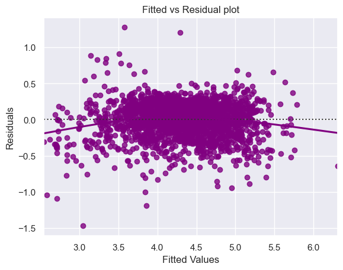

```python
# let's plot the fitted values vs residuals

sns.residplot(
    data=df_pred, x="Fitted Values", y="Residuals", color="purple", lowess=True
)
plt.xlabel("Fitted Values")
plt.ylabel("Residuals")
plt.title("Fitted vs Residual plot")
plt.show()
```

### TEST FOR NORMALITY

**Why the test?**

- Error terms, or residuals, should be normally distributed. If the error terms are not normally distributed, confidence intervals of the coefficient estimates may become too wide or narrow. Once confidence interval becomes unstable, it leads to difficulty in estimating coefficients based on minimization of least squares. Non-normality suggests that there are a few unusual data points that must be studied closely to make a better model.

**How to check normality?**

- The shape of the histogram of residuals can give an initial idea about the normality.
- It can also be checked via a Q-Q plot of residuals. If the residuals follow a normal distribution, they will make a straight line plot, otherwise not.
- Other tests to check for normality includes the Shapiro-Wilk test.
  - Null hypothesis: Residuals are normally distributed
  - Alternate hypothesis: Residuals are not normally distributed

**How to fix if this assumption is not followed?**

- We can apply transformations like log, exponential, arcsinh, etc. as per our data.

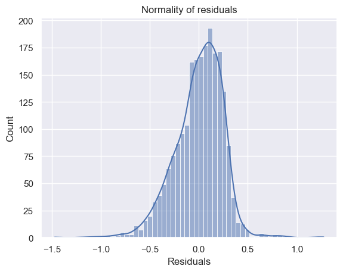

```python
sns.histplot(data=df_pred, x="Residuals", kde=True)
plt.title("Normality of residuals")
plt.show()
```

- The histogram of residuals does have a bell shape.
- Let's check the Q-Q plot.

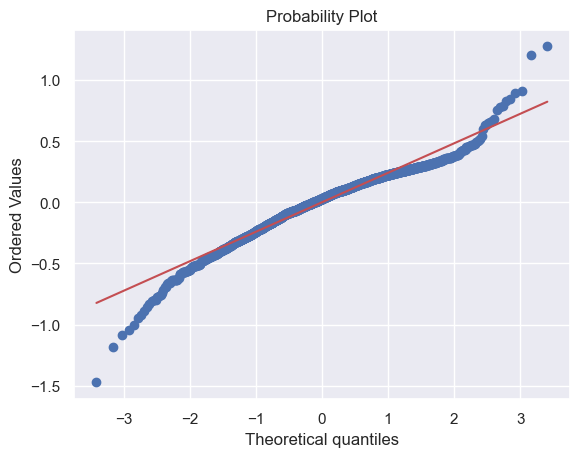

```python
import pylab
import scipy.stats as stats

stats.probplot(df_pred["Residuals"], dist="norm", plot=pylab)
plt.show()
```

- The residuals more or less follow a straight line except for the tails.
- Let's check the results of the Shapiro-Wilk test.

```python
stats.shapiro(df_pred["Residuals"])
```

```
ShapiroResult(statistic=0.965074896812439, pvalue=2.5140805198421496e-22)
```

- Since p-value < 0.05, the residuals are not normal as per the Shapiro-Wilk test.
- Strictly speaking, the residuals are not normal.
- However, as an approximation, we can accept this distribution as close to being normal.
- **So, the assumption is satisfied.**

### TEST FOR HOMOSCEDASTICITY

- **Homoscedascity**: If the variance of the residuals is symmetrically distributed across the regression line, then the data is said to be homoscedastic.
- **Heteroscedascity**: If the variance is unequal for the residuals across the regression line, then the data is said to be heteroscedastic.

**Why the test?**

- The presence of non-constant variance in the error terms results in heteroscedasticity. Generally, non-constant variance arises in presence of outliers.

**How to check for homoscedasticity?**

- The residual vs fitted values plot can be looked at to check for homoscedasticity. In the case of heteroscedasticity, the residuals can form an arrow shape or any other non-symmetrical shape.
- The goldfeldquandt test can also be used. If we get a p-value > 0.05 we can say that the residuals are homoscedastic. Otherwise, they are heteroscedastic.
  - Null hypothesis: Residuals are homoscedastic
  - Alternate hypothesis: Residuals have heteroscedasticity

**How to fix if this assumption is not followed?**

- Heteroscedasticity can be fixed by adding other important features or making transformations.

```python
import statsmodels.stats.api as sms
from statsmodels.compat import lzip

name = ["F statistic", "p-value"]
test = sms.het_goldfeldquandt(df_pred["Residuals"], x_train3)
lzip(name, test)
```

```
[('F statistic', 0.8936688582022313), ('p-value', 0.9659213295120914)]
```

**Since p-value > 0.05, we can say that the residuals are homoscedastic. So, this assumption is satisfied.**

## Predictions on test data

Now that we have checked all the assumptions of linear regression and they are satisfied, let's go ahead with prediction.

```python
# predictions on the test set
pred = olsmod2.predict(x_test3)

df_pred_test_phone = pd.DataFrame({"Actual": y_test, "Predicted": pred})
df_pred_test_phone.sample(10, random_state=1)
```

|  | Actual | Predicted |
| --- | --- | --- |
| 2645 | 3.905 | 4.041 |
| 337 | 5.483 | 5.228 |
| 2699 | 4.848 | 4.701 |
| 1495 | 4.610 | 4.435 |
| 147 | 5.036 | 4.972 |
| 235 | 5.180 | 5.071 |
| 3345 | 5.483 | 5.330 |
| 264 | 5.530 | 5.279 |
| 2068 | 3.882 | 4.165 |
| 2240 | 4.263 | 3.979 |

- We can observe here that our model has returned pretty good prediction results, and the actual and predicted values are comparable

## Final Model

Let's recreate the final model and print it's summary to gain insights.

```python
x_train_final = x_train3.copy()
x_test_final = x_test3.copy()
```

```python
olsmodel_final = sm.OLS(y_train, x_train_final).fit()
print(olsmodel_final.summary())
```

```
                              OLS Regression Results
=================================================================================
Dep. Variable:     normalized_used_price   R-squared:                       0.832
Model:                               OLS   Adj. R-squared:                  0.831
Method:                    Least Squares   F-statistic:                     808.0
Date:                   Sun, 18 Jun 2023   Prob (F-statistic):               0.00
Time:                           23:31:00   Log-Likelihood:                -29.400
No. Observations:                   2136   AIC:                             86.80
Df Residuals:                       2122   BIC:                             166.1
Df Model:                             13
Covariance Type:               nonrobust
========================================================================================
                           coef    std err          t      P>|t|      [0.025      0.975]
----------------------------------------------------------------------------------------
const                    1.3082      0.059     22.348      0.000       1.193       1.423
main_camera_mp           0.0241      0.002     14.774      0.000       0.021       0.027
selfie_camera_mp         0.0163      0.001     14.844      0.000       0.014       0.018
ram                      0.0165      0.005      3.257      0.001       0.007       0.027
battery                3.76e-05   1.04e-05      3.631      0.000    1.73e-05    5.79e-05
weight                   0.0017      0.000      5.962      0.000       0.001       0.002
days_used            -6.366e-05   2.85e-05     -2.231      0.026      -0.000   -7.71e-06
normalized_new_price     0.4241      0.012     35.949      0.000       0.401       0.447
brand_name_Nokia         0.1087      0.032      3.368      0.001       0.045       0.172
brand_name_Realme        0.1540      0.044      3.492      0.000       0.068       0.241
brand_name_Sony         -0.0833      0.034     -2.475      0.013      -0.149      -0.017
brand_name_Xiaomi        0.0845      0.028      3.022      0.003       0.030       0.139
os_Others               -0.1592      0.030     -5.356      0.000      -0.217      -0.101
4g_yes                   0.0820      0.016      4.976      0.000       0.050       0.114
==============================================================================
Omnibus:                      209.269   Durbin-Watson:                   1.942
Prob(Omnibus):                  0.000   Jarque-Bera (JB):              530.791
Skew:                          -0.557   Prob(JB):                    5.50e-116
Kurtosis:                       5.174   Cond. No.                     3.54e+04
==============================================================================

Notes:
[1] Standard Errors assume that the covariance matrix of the errors is correctly specified.
[2] The condition number is large, 3.54e+04. This might indicate that there are
strong multicollinearity or other numerical problems.
```

```python
# checking model performance on train set (seen 70% data)
print("Training Performance\n")
olsmodel_final_train_perf = model_performance_regression(
    olsmodel_final, x_train_final, y_train
)
olsmodel_final_train_perf
```

```
Training Performance
```

|  | RMSE | MAE | R-squared | Adj. R-squared | MAPE |
| --- | --- | --- | --- | --- | --- |
| 0 | 0.245 | 0.189 | 0.832 | 0.831 | 4.607 |

```python
# checking model performance on test set (seen 30% data)
print("Test Performance\n")
olsmodel_final_test_perf = model_performance_regression(
    olsmodel_final, x_test_final, y_test
)
olsmodel_final_test_perf
```

```
Test Performance
```

|  | RMSE | MAE | R-squared | Adj. R-squared | MAPE |
| --- | --- | --- | --- | --- | --- |
| 0 | 0.224 | 0.180 | 0.853 | 0.850 | 4.318 |

## Actionable Insights and Recommendations Phone

# Tablets Regression

### Data Preparation for Modeling

- We want to predict the normalized_used_price of an used tablets.
- Before we proceed to build a model, we'll have to encode categorical features
- We'll split the data into train and test to be able to evaluate the model that we build on the train data
- We will build a Linear Regression model using the train data and then check it's performance

```python
df_tablet
```

|  | brand_name | os | screen_size | 4g | 5g | main_camera_mp | selfie_camera_mp | int_memory | ram | battery | weight | release_year | days_used | normalized_used_price | normalized_new_price | device_type |
| --- | --- | --- | --- | --- | --- | --- | --- | --- | --- | --- | --- | --- | --- | --- | --- | --- |
| 1 | Honor | Android | 17.300 | yes | yes | 13.000 | 16.000 | 128.000 | 8.000 | 4300.000 | 213.000 | 2020 | 325 | 5.162 | 5.519 | Tablet |
| 3 | Honor | Android | 25.500 | yes | yes | 13.000 | 8.000 | 64.000 | 6.000 | 7250.000 | 480.000 | 2020 | 345 | 5.135 | 5.631 | Tablet |
| 19 | Honor | Android | 25.430 | yes | no | 5.000 | 2.000 | 32.000 | 3.000 | 5100.000 | 173.000 | 2019 | 266 | 4.268 | 5.517 | Tablet |
| 20 | Honor | Android | 20.320 | yes | no | 8.000 | 8.000 | 32.000 | 3.000 | 5100.000 | 173.000 | 2019 | 321 | 4.556 | 5.304 | Tablet |
| 21 | Others | Android | 20.320 | no | no | 8.000 | 0.300 | 16.000 | 1.000 | 5680.000 | 453.600 | 2013 | 933 | 4.452 | 5.484 | Tablet |
| ... | ... | ... | ... | ... | ... | ... | ... | ... | ... | ... | ... | ... | ... | ... | ... | ... |
| 3216 | Huawei | Android | 17.830 | yes | yes | 13.000 | 24.000 | 256.000 | 8.000 | 4200.000 | 233.000 | 2019 | 279 | 5.157 | 6.192 | Tablet |
| 3304 | Xiaomi | Android | 17.810 | yes | yes | 8.000 | 20.000 | 256.000 | 8.000 | 5000.000 | 253.000 | 2020 | 361 | 5.224 | 6.509 | Tablet |
| 3348 | Huawei | Android | 20.320 | yes | yes | 10.500 | 16.000 | 512.000 | 8.000 | 4500.000 | 300.000 | 2020 | 129 | 5.959 | 7.848 | Tablet |
| 3357 | Huawei | Android | 17.830 | yes | yes | 13.000 | 24.000 | 256.000 | 8.000 | 4200.000 | 233.000 | 2019 | 351 | 5.299 | 6.192 | Tablet |
| 3436 | Samsung | Android | 17.860 | yes | yes | 12.000 | 9.000 | 512.000 | 12.000 | 4235.000 | 263.000 | 2019 | 434 | 5.574 | 7.333 | Tablet |

402 rows × 16 columns

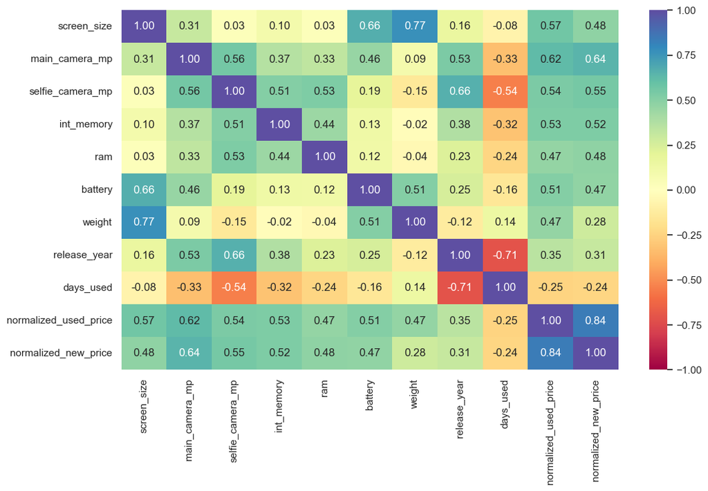

```python
plt.figure(figsize=(12, 7))
sns.heatmap(
    df_tablet.corr(), annot=True, vmin=-1, vmax=1, fmt=".2f", cmap="Spectral"
)
plt.show()
```

```python
Xt= df_tablet.drop(["normalized_used_price"],axis=1)
yt= df_tablet["normalized_used_price"]
print(Xt.head())
print(yt.head())
```

```
   brand_name       os  screen_size   4g   5g  main_camera_mp  \
1       Honor  Android       17.300  yes  yes          13.000
3       Honor  Android       25.500  yes  yes          13.000
19      Honor  Android       25.430  yes   no           5.000
20      Honor  Android       20.320  yes   no           8.000
21     Others  Android       20.320   no   no           8.000

    selfie_camera_mp  int_memory   ram  battery  weight  release_year  \
1             16.000     128.000 8.000 4300.000 213.000          2020
3              8.000      64.000 6.000 7250.000 480.000          2020
19             2.000      32.000 3.000 5100.000 173.000          2019
20             8.000      32.000 3.000 5100.000 173.000          2019
21             0.300      16.000 1.000 5680.000 453.600          2013

    days_used  normalized_new_price device_type
1         325                 5.519      Tablet
3         345                 5.631      Tablet
19        266                 5.517      Tablet
20        321                 5.304      Tablet
21        933                 5.484      Tablet
1    5.162
3    5.135
19   4.268
20   4.556
21   4.452
Name: normalized_used_price, dtype: float64
```

```python
Xt = sm.add_constant(Xt)
```

```python
Xt.head()
```

|  | const | brand_name | os | screen_size | 4g | 5g | main_camera_mp | selfie_camera_mp | int_memory | ram | battery | weight | release_year | days_used | normalized_new_price | device_type |
| --- | --- | --- | --- | --- | --- | --- | --- | --- | --- | --- | --- | --- | --- | --- | --- | --- |
| 1 | 1.000 | Honor | Android | 17.300 | yes | yes | 13.000 | 16.000 | 128.000 | 8.000 | 4300.000 | 213.000 | 2020 | 325 | 5.519 | Tablet |
| 3 | 1.000 | Honor | Android | 25.500 | yes | yes | 13.000 | 8.000 | 64.000 | 6.000 | 7250.000 | 480.000 | 2020 | 345 | 5.631 | Tablet |
| 19 | 1.000 | Honor | Android | 25.430 | yes | no | 5.000 | 2.000 | 32.000 | 3.000 | 5100.000 | 173.000 | 2019 | 266 | 5.517 | Tablet |
| 20 | 1.000 | Honor | Android | 20.320 | yes | no | 8.000 | 8.000 | 32.000 | 3.000 | 5100.000 | 173.000 | 2019 | 321 | 5.304 | Tablet |
| 21 | 1.000 | Others | Android | 20.320 | no | no | 8.000 | 0.300 | 16.000 | 1.000 | 5680.000 | 453.600 | 2013 | 933 | 5.484 | Tablet |

```python
# creating dummy variables
Xt = pd.get_dummies(
    Xt,
    columns=Xt.select_dtypes(include=["object", "category"]).columns.tolist(),
    drop_first=True,
)
Xt.head()
```

|  | const | screen_size | main_camera_mp | selfie_camera_mp | int_memory | ram | battery | weight | release_year | days_used | ... | brand_name_Sony | brand_name_Spice | brand_name_Vivo | brand_name_XOLO | brand_name_Xiaomi | os_Others | os_Windows | os_iOS | 4g_yes | 5g_yes |
| --- | --- | --- | --- | --- | --- | --- | --- | --- | --- | --- | --- | --- | --- | --- | --- | --- | --- | --- | --- | --- | --- |
| 1 | 1.000 | 17.300 | 13.000 | 16.000 | 128.000 | 8.000 | 4300.000 | 213.000 | 2020 | 325 | ... | 0 | 0 | 0 | 0 | 0 | 0 | 0 | 0 | 1 | 1 |
| 3 | 1.000 | 25.500 | 13.000 | 8.000 | 64.000 | 6.000 | 7250.000 | 480.000 | 2020 | 345 | ... | 0 | 0 | 0 | 0 | 0 | 0 | 0 | 0 | 1 | 1 |
| 19 | 1.000 | 25.430 | 5.000 | 2.000 | 32.000 | 3.000 | 5100.000 | 173.000 | 2019 | 266 | ... | 0 | 0 | 0 | 0 | 0 | 0 | 0 | 0 | 1 | 0 |
| 20 | 1.000 | 20.320 | 8.000 | 8.000 | 32.000 | 3.000 | 5100.000 | 173.000 | 2019 | 321 | ... | 0 | 0 | 0 | 0 | 0 | 0 | 0 | 0 | 1 | 0 |
| 21 | 1.000 | 20.320 | 8.000 | 0.300 | 16.000 | 1.000 | 5680.000 | 453.600 | 2013 | 933 | ... | 0 | 0 | 0 | 0 | 0 | 0 | 0 | 0 | 0 | 0 |

5 rows × 37 columns

```python
xt_train,xt_test,yt_train,yt_test = train_test_split(Xt, yt, test_size=0.3, random_state=1)
```

```python
print("Number of rows in train data =", xt_train.shape[0])
print("Number of rows in test data =", xt_test.shape[0])
```

```
Number of rows in train data = 281
Number of rows in test data = 121
```

## Model Building - Linear Regression

```python
olsmodelt = sm.OLS(yt_train, xt_train).fit()
print(olsmodelt.summary())
```

```
                              OLS Regression Results
=================================================================================
Dep. Variable:     normalized_used_price   R-squared:                       0.820
Model:                               OLS   Adj. R-squared:                  0.795
Method:                    Least Squares   F-statistic:                     32.93
Date:                   Sun, 18 Jun 2023   Prob (F-statistic):           4.53e-73
Time:                           23:31:04   Log-Likelihood:                 66.743
No. Observations:                    281   AIC:                            -63.49
Df Residuals:                        246   BIC:                             63.86
Df Model:                             34
Covariance Type:               nonrobust
========================================================================================
                           coef    std err          t      P>|t|      [0.025      0.975]
----------------------------------------------------------------------------------------
const                   12.2072     22.130      0.552      0.582     -31.381      55.796
screen_size              0.0008      0.008      0.098      0.922      -0.016       0.017
main_camera_mp           0.0120      0.006      1.852      0.065      -0.001       0.025
selfie_camera_mp         0.0149      0.008      1.953      0.052      -0.000       0.030
int_memory               0.0004      0.000      2.126      0.035    3.08e-05       0.001
ram                      0.0464      0.015      3.021      0.003       0.016       0.077
battery              -4.681e-06   1.23e-05     -0.381      0.703   -2.89e-05    1.95e-05
weight                   0.0013      0.000      6.895      0.000       0.001       0.002
release_year            -0.0051      0.011     -0.462      0.644      -0.027       0.017
days_used            -2.773e-05   7.79e-05     -0.356      0.722      -0.000       0.000
normalized_new_price     0.3386      0.046      7.429      0.000       0.249       0.428
brand_name_Alcatel       0.0376      0.093      0.405      0.686      -0.145       0.220
brand_name_Apple         0.3410      0.268      1.271      0.205      -0.187       0.869
brand_name_Asus         -0.0078      0.084     -0.093      0.926      -0.174       0.158
brand_name_Google        0.0801      0.222      0.361      0.719      -0.357       0.518
brand_name_HTC           0.2081      0.221      0.942      0.347      -0.227       0.643
brand_name_Honor        -0.0201      0.108     -0.187      0.852      -0.232       0.192
brand_name_Huawei       -0.0284      0.088     -0.325      0.746      -0.201       0.144
brand_name_Infinix    -2.53e-16   2.38e-16     -1.064      0.288   -7.21e-16    2.15e-16
brand_name_Karbonn       0.0605      0.164      0.369      0.713      -0.263       0.384
brand_name_LG           -0.0450      0.098     -0.458      0.647      -0.239       0.148
brand_name_Lenovo        0.0130      0.083      0.156      0.876      -0.151       0.177
brand_name_Micromax     -0.0958      0.127     -0.752      0.453      -0.347       0.155
brand_name_Microsoft  -2.18e-16   2.06e-16     -1.057      0.292   -6.24e-16    1.88e-16
brand_name_Nokia        -0.1269      0.235     -0.541      0.589      -0.589       0.335
brand_name_Others       -0.0476      0.078     -0.608      0.544      -0.202       0.107
brand_name_Samsung      -0.0528      0.083     -0.639      0.523      -0.216       0.110
brand_name_Sony         -0.0390      0.117     -0.333      0.740      -0.270       0.192
brand_name_Spice        -0.1179      0.219     -0.539      0.590      -0.549       0.313
brand_name_Vivo         -0.1260      0.161     -0.784      0.434      -0.443       0.191
brand_name_XOLO         -0.1018      0.139     -0.732      0.465      -0.376       0.172
brand_name_Xiaomi        0.0769      0.146      0.528      0.598      -0.210       0.364
os_Others               -0.1086      0.206     -0.527      0.599      -0.515       0.298
os_Windows              -0.0885      0.314     -0.282      0.778      -0.707       0.530
os_iOS                  -0.5230      0.262     -1.998      0.047      -1.038      -0.008
4g_yes                   0.0729      0.037      1.997      0.047       0.001       0.145
5g_yes                  -0.0171      0.093     -0.183      0.855      -0.201       0.167
==============================================================================
Omnibus:                       72.184   Durbin-Watson:                   2.068
Prob(Omnibus):                  0.000   Jarque-Bera (JB):              209.330
Skew:                          -1.134   Prob(JB):                     3.50e-46
Kurtosis:                       6.568   Cond. No.                     1.05e+16
==============================================================================

Notes:
[1] Standard Errors assume that the covariance matrix of the errors is correctly specified.
[2] The smallest eigenvalue is 8.46e-23. This might indicate that there are
strong multicollinearity problems or that the design matrix is singular.
```

### Interpreting the Regression Results:

1. **Adjusted. R-squared**: It reflects the fit of the model.
   - Adjusted R-squared values generally range from 0 to 1, where a higher value generally indicates a better fit, assuming certain conditions are met.
   - In our case, the value for adj. R-squared is **0.795**, which is good.
1. *const* coefficient: It is the Y-intercept.
   - It means that if all the predictor variable coefficients are zero, then the expected output (i.e., Y) would be equal to the *const* coefficient.
   - In our case, the value for `const` coefficient is **12.207**
1. **Coefficient of a predictor variable**: It represents the change in the output Y due to a change in the predictor variable (everything else held constant).
   - In our case, the coefficient of `selfie_camera_mp` is **0.0149**.

## Model Performance Check

Let's check the performance of the model using different metrics.

- We will be using metric functions defined in sklearn for RMSE, MAE, and $R^2$.
- We will define a function to calculate MAPE and adjusted $R^2$.
  - The mean absolute percentage error (MAPE) measures the accuracy of predictions as a percentage, and can be calculated as the average absolute percent error for each predicted value minus actual values divided by actual values. It works best if there are no extreme values in the data and none of the actual values are 0.
- We will create a function which will print out all the above metrics in one go.

```python
# function to compute adjusted R-squared
def adj_r2_score(predictors, targets, predictions):
    r2 = r2_score(targets, predictions)
    n = predictors.shape[0]
    k = predictors.shape[1]
    return 1 - ((1 - r2) * (n - 1) / (n - k - 1))


# function to compute MAPE
def mape_score(targets, predictions):
    return np.mean(np.abs(targets - predictions) / targets) * 100


# function to compute different metrics to check performance of a regression model
def model_performance_regression(model, predictors, target):
    """
    Function to compute different metrics to check regression model performance

    model: regressor
    predictors: independent variables
    target: dependent variable
    """

    # predicting using the independent variables
    pred = model.predict(predictors)

    r2 = r2_score(target, pred)  # to compute R-squared
    adjr2 = adj_r2_score(predictors, target, pred)  # to compute adjusted R-squared
    rmse = np.sqrt(mean_squared_error(target, pred))  # to compute RMSE
    mae = mean_absolute_error(target, pred)  # to compute MAE
    mape = mape_score(target, pred)  # to compute MAPE

    # creating a dataframe of metrics
    df_perf = pd.DataFrame(
        {
            "RMSE": rmse,
            "MAE": mae,
            "R-squared": r2,
            "Adj. R-squared": adjr2,
            "MAPE": mape,
        },
        index=[0],
    )

    return df_perf
```

```python
# checking model performance on train set (seen 70% data)
print("Training Performance\n")
olsmodelt_train_perf = model_performance_regression(olsmodelt, xt_train, yt_train)
olsmodelt_train_perf
```

```
Training Performance
```

|  | RMSE | MAE | R-squared | Adj. R-squared | MAPE |
| --- | --- | --- | --- | --- | --- |
| 0 | 0.191 | 0.146 | 0.820 | 0.792 | 3.246 |

```python
print("Test Performance\n")
olsmodelt_test_perf = model_performance_regression(olsmodelt, xt_test, yt_test)
olsmodelt_test_perf
```

```
Test Performance
```

|  | RMSE | MAE | R-squared | Adj. R-squared | MAPE |
| --- | --- | --- | --- | --- | --- |
| 0 | 0.190 | 0.155 | 0.841 | 0.770 | 3.265 |

## Checking Linear Regression Assumptions

We will be checking the following Linear Regression assumptions:

1. **No Multicollinearity**
2. **Linearity of variables**
3. **Independence of error terms**
4. **Normality of error terms**
5. **No Heteroscedasticity**

### TEST FOR MULTICOLLINEARITY

Multicollinearity occurs when predictor variables in a regression model are correlated. This correlation is a problem because predictor variables should be independent. If the correlation between variables is high, it can cause problems when we fit the model and interpret the results. When we have multicollinearity in the linear model, the coefficients that the model suggests are unreliable.

There are different ways of detecting (or testing) multicollinearity. One such way is by using the Variance Inflation Factor, or VIF.

Variance Inflation Factor (VIF): Variance inflation factors measure the inflation in the variances of the regression parameter estimates due to collinearities that exist among the predictors. It is a measure of how much the variance of the estimated regression coefficient 𝛽𝑘 is "inflated" by the existence of correlation among the predictor variables in the model.

If VIF is 1, then there is no correlation among the 𝑘 th predictor and the remaining predictor variables, and hence, the variance of 𝛽𝑘 is not inflated at all. General Rule of thumb:

If VIF is between 1 and 5, then there is low multicollinearity. If VIF is between 5 and 10, we say there is moderate multicollinearity. If VIF is exceeding 10, it shows signs of high multicollinearity.

Let's define a function to check VIF.

```python
from statsmodels.stats.outliers_influence import variance_inflation_factor


def checking_vif(predictors):
    vif = pd.DataFrame()
    vif["feature"] = predictors.columns

    # calculating VIF for each feature
    vif["VIF"] = [
        variance_inflation_factor(predictors.values, i)
        for i in range(len(predictors.columns))
    ]
    return vif
```

```python
predictors
```

|  | const | main_camera_mp | selfie_camera_mp | int_memory | ram | battery | weight | days_used | normalized_new_price | brand_name_Alcatel | ... | brand_name_Spice | brand_name_Vivo | brand_name_XOLO | brand_name_Xiaomi | brand_name_ZTE | os_Others | os_Windows | os_iOS | 4g_yes | 5g_yes |
| --- | --- | --- | --- | --- | --- | --- | --- | --- | --- | --- | --- | --- | --- | --- | --- | --- | --- | --- | --- | --- | --- |
| 2822 | 1.000 | 13.000 | 12.000 | 64.000 | 4.000 | 3315.000 | 164.000 | 477 | 5.522 | 0 | ... | 0 | 1 | 0 | 0 | 0 | 0 | 0 | 0 | 1 | 0 |
| 1977 | 1.000 | 12.000 | 8.000 | 64.000 | 4.000 | 3000.000 | 167.000 | 561 | 5.198 | 0 | ... | 0 | 0 | 0 | 0 | 0 | 0 | 0 | 0 | 1 | 0 |
| 3113 | 1.000 | 13.000 | 5.000 | 16.000 | 4.000 | 3000.000 | 164.000 | 800 | 5.302 | 0 | ... | 0 | 0 | 0 | 0 | 1 | 0 | 0 | 0 | 1 | 0 |
| 565 | 1.000 | 2.000 | 0.300 | 512.000 | 0.250 | 1400.000 | 118.000 | 911 | 4.602 | 1 | ... | 0 | 0 | 0 | 0 | 0 | 0 | 0 | 0 | 0 | 0 |
| 2828 | 1.000 | 13.000 | 25.000 | 64.000 | 4.000 | 3400.000 | 156.000 | 408 | 5.856 | 0 | ... | 0 | 1 | 0 | 0 | 0 | 0 | 0 | 0 | 1 | 0 |
| ... | ... | ... | ... | ... | ... | ... | ... | ... | ... | ... | ... | ... | ... | ... | ... | ... | ... | ... | ... | ... | ... |
| 3159 | 1.000 | 8.000 | 5.000 | 32.000 | 4.000 | 2300.000 | 135.550 | 593 | 5.139 | 0 | ... | 0 | 0 | 0 | 0 | 1 | 0 | 0 | 0 | 0 | 0 |
| 1087 | 1.000 | 13.000 | 5.000 | 32.000 | 4.000 | 3000.000 | 160.000 | 556 | 4.784 | 0 | ... | 0 | 0 | 0 | 0 | 0 | 0 | 0 | 0 | 1 | 0 |
| 1304 | 1.000 | 13.000 | 5.000 | 16.000 | 4.000 | 3020.000 | 145.000 | 699 | 5.019 | 0 | ... | 0 | 0 | 0 | 0 | 0 | 0 | 0 | 0 | 1 | 0 |
| 275 | 1.000 | 13.000 | 16.000 | 64.000 | 4.000 | 4000.000 | 196.800 | 330 | 5.638 | 0 | ... | 0 | 0 | 0 | 0 | 0 | 0 | 0 | 0 | 1 | 0 |
| 1260 | 1.000 | 13.000 | 8.000 | 64.000 | 4.000 | 3400.000 | 160.000 | 381 | 5.292 | 0 | ... | 0 | 0 | 0 | 0 | 0 | 0 | 0 | 0 | 1 | 0 |

2136 rows × 47 columns

```python
pd.set_option('display.float_format', lambda x: '%.3f' % x)
```

```python
checking_vif(xt_train)
```

|  | feature | VIF |
| --- | --- | --- |
| 0 | const | 3308889.637 |
| 1 | screen_size | 5.549 |
| 2 | main_camera_mp | 3.694 |
| 3 | selfie_camera_mp | 6.057 |
| 4 | int_memory | 2.026 |
| 5 | ram | 2.401 |
| 6 | battery | 3.443 |
| 7 | weight | 4.206 |
| 8 | release_year | 4.355 |
| 9 | days_used | 2.381 |
| 10 | normalized_new_price | 5.610 |
| 11 | brand_name_Alcatel | 3.125 |
| 12 | brand_name_Apple | 23.011 |
| 13 | brand_name_Asus | 3.899 |
| 14 | brand_name_Google | 1.182 |
| 15 | brand_name_HTC | 1.169 |
| 16 | brand_name_Honor | 2.946 |
| 17 | brand_name_Huawei | 5.508 |
| 18 | brand_name_Infinix | NaN |
| 19 | brand_name_Karbonn | 1.286 |
| 20 | brand_name_LG | 2.453 |
| 21 | brand_name_Lenovo | 5.256 |
| 22 | brand_name_Micromax | 1.539 |
| 23 | brand_name_Microsoft | NaN |
| 24 | brand_name_Nokia | 3.932 |
| 25 | brand_name_Others | 6.352 |
| 26 | brand_name_Samsung | 6.322 |
| 27 | brand_name_Sony | 1.935 |
| 28 | brand_name_Spice | 1.146 |
| 29 | brand_name_Vivo | 1.845 |
| 30 | brand_name_XOLO | 1.379 |
| 31 | brand_name_Xiaomi | 1.515 |
| 32 | os_Others | 3.035 |
| 33 | os_Windows | 2.361 |
| 34 | os_iOS | 18.916 |
| 35 | 4g_yes | 2.245 |
| 36 | 5g_yes | 2.603 |

- There are multiple columns with very high VIF values, indicating presence of strong multicollinearity
- We will systematically drop numerical columns with VIF > 5
- We will ignore the VIF values for dummy variables and the constant (intercept)

### Removing Multicollinearity

To remove multicollinearity

1. Drop every column one by one that has a VIF score greater than 5.
2. Look at the adjusted R-squared and RMSE of all these models.
3. Drop the variable that makes the least change in adjusted R-squared.
4. Check the VIF scores again.
5. Continue till you get all VIF scores under 5.

Let's define a function that will help us do this.

```python
def treating_multicollinearity(predictors, target, high_vif_columns):
    """
    Checking the effect of dropping the columns showing high multicollinearity
    on model performance (adj. R-squared and RMSE)

    predictors: independent variables
    target: dependent variable
    high_vif_columns: columns having high VIF
    """
    # empty lists to store adj. R-squared and RMSE values
    adj_r2 = []
    rmse = []

    # build ols models by dropping one of the high VIF columns at a time
    # store the adjusted R-squared and RMSE in the lists defined previously
    for cols in high_vif_columns:
        # defining the new train set
        train = predictors.loc[:, ~predictors.columns.str.startswith(cols)]

        # create the model
        olsmodel = sm.OLS(target, train).fit()

        # adding adj. R-squared and RMSE to the lists
        adj_r2.append(olsmodel.rsquared_adj)
        rmse.append(np.sqrt(olsmodel.mse_resid))

    # creating a dataframe for the results
    temp = pd.DataFrame(
        {
            "col": high_vif_columns,
            "Adj. R-squared after_dropping col": adj_r2,
            "RMSE after dropping col": rmse,
        }
    ).sort_values(by="Adj. R-squared after_dropping col", ascending=False)
    temp.reset_index(drop=True, inplace=True)

    return temp
```

```python
col_list = ["screen_size", "selfie_camera_mp"]

res = treating_multicollinearity(xt_train, yt_train, col_list)
res
```

|  | col | Adj. R-squared after_dropping col | RMSE after dropping col |
| --- | --- | --- | --- |
| 0 | screen_size | 0.796 | 0.204 |
| 1 | selfie_camera_mp | 0.793 | 0.205 |

```python
col_to_drop = "screen_size"
xt_train1 = xt_train.loc[:, ~xt_train.columns.str.startswith(col_to_drop)]
xt_test1 = xt_test.loc[:, ~xt_test.columns.str.startswith(col_to_drop)]

# Check VIF now
vif = checking_vif(xt_train1)
print("VIF after dropping ", col_to_drop)
vif
```

```
VIF after dropping  screen_size
```

|  | feature | VIF |
| --- | --- | --- |
| 0 | const | 2958934.400 |
| 1 | main_camera_mp | 3.694 |
| 2 | selfie_camera_mp | 5.687 |
| 3 | int_memory | 2.026 |
| 4 | ram | 2.400 |
| 5 | battery | 3.040 |
| 6 | weight | 2.409 |
| 7 | release_year | 3.886 |
| 8 | days_used | 2.379 |
| 9 | normalized_new_price | 5.254 |
| 10 | brand_name_Alcatel | 3.115 |
| 11 | brand_name_Apple | 23.011 |
| 12 | brand_name_Asus | 3.891 |
| 13 | brand_name_Google | 1.181 |
| 14 | brand_name_HTC | 1.160 |
| 15 | brand_name_Honor | 2.917 |
| 16 | brand_name_Huawei | 5.506 |
| 17 | brand_name_Infinix | NaN |
| 18 | brand_name_Karbonn | 1.285 |
| 19 | brand_name_LG | 2.453 |
| 20 | brand_name_Lenovo | 5.243 |
| 21 | brand_name_Micromax | 1.523 |
| 22 | brand_name_Microsoft | NaN |
| 23 | brand_name_Nokia | 3.919 |
| 24 | brand_name_Others | 6.349 |
| 25 | brand_name_Samsung | 6.315 |
| 26 | brand_name_Sony | 1.886 |
| 27 | brand_name_Spice | 1.139 |
| 28 | brand_name_Vivo | 1.843 |
| 29 | brand_name_XOLO | 1.374 |
| 30 | brand_name_Xiaomi | 1.480 |
| 31 | os_Others | 3.035 |
| 32 | os_Windows | 2.359 |
| 33 | os_iOS | 18.858 |
| 34 | 4g_yes | 2.245 |
| 35 | 5g_yes | 2.557 |

```python
olsmod1t1 = sm.OLS(yt_train, xt_train1).fit()
print(olsmod1t1.summary())
```

```
                              OLS Regression Results
=================================================================================
Dep. Variable:     normalized_used_price   R-squared:                       0.820
Model:                               OLS   Adj. R-squared:                  0.796
Method:                    Least Squares   F-statistic:                     34.06
Date:                   Sun, 18 Jun 2023   Prob (F-statistic):           7.72e-74
Time:                           23:31:10   Log-Likelihood:                 66.737
No. Observations:                    281   AIC:                            -65.47
Df Residuals:                        247   BIC:                             58.23
Df Model:                             33
Covariance Type:               nonrobust
========================================================================================
                           coef    std err          t      P>|t|      [0.025      0.975]
----------------------------------------------------------------------------------------
const                   11.5004     20.885      0.551      0.582     -29.635      52.636
main_camera_mp           0.0119      0.006      1.856      0.065      -0.001       0.025
selfie_camera_mp         0.0147      0.007      1.995      0.047       0.000       0.029
int_memory               0.0004      0.000      2.130      0.034    3.15e-05       0.001
ram                      0.0465      0.015      3.029      0.003       0.016       0.077
battery              -4.268e-06   1.15e-05     -0.371      0.711    -2.7e-05    1.84e-05
weight                   0.0013      0.000      9.215      0.000       0.001       0.002
release_year            -0.0047      0.010     -0.456      0.649      -0.025       0.016
days_used            -2.797e-05   7.77e-05     -0.360      0.719      -0.000       0.000
normalized_new_price     0.3397      0.044      7.718      0.000       0.253       0.426
brand_name_Alcatel       0.0381      0.092      0.412      0.681      -0.144       0.220
brand_name_Apple         0.3410      0.268      1.274      0.204      -0.186       0.868
brand_name_Asus         -0.0082      0.084     -0.098      0.922      -0.174       0.157
brand_name_Google        0.0795      0.222      0.359      0.720      -0.357       0.516
brand_name_HTC           0.2062      0.220      0.939      0.349      -0.226       0.639
brand_name_Honor        -0.0191      0.107     -0.178      0.859      -0.230       0.192
brand_name_Huawei       -0.0286      0.087     -0.327      0.744      -0.201       0.143
brand_name_Infinix    6.499e-13      6e-13      1.083      0.280   -5.32e-13    1.83e-12
brand_name_Karbonn       0.0609      0.164      0.372      0.710      -0.262       0.383
brand_name_LG           -0.0451      0.098     -0.460      0.646      -0.238       0.148
brand_name_Lenovo        0.0126      0.083      0.152      0.880      -0.151       0.176
brand_name_Micromax     -0.0946      0.127     -0.748      0.455      -0.344       0.155
brand_name_Microsoft -7.581e-14      7e-14     -1.083      0.280   -2.14e-13    6.21e-14
brand_name_Nokia        -0.1256      0.234     -0.537      0.592      -0.586       0.335
brand_name_Others       -0.0478      0.078     -0.612      0.541      -0.202       0.106
brand_name_Samsung      -0.0526      0.082     -0.637      0.524      -0.215       0.110
brand_name_Sony         -0.0371      0.115     -0.322      0.748      -0.264       0.190
brand_name_Spice        -0.1195      0.218     -0.549      0.583      -0.548       0.309
brand_name_Vivo         -0.1265      0.160     -0.789      0.431      -0.442       0.189
brand_name_XOLO         -0.1026      0.138     -0.741      0.459      -0.375       0.170
brand_name_Xiaomi        0.0748      0.144      0.520      0.603      -0.208       0.358
os_Others               -0.1088      0.206     -0.528      0.598      -0.514       0.297
os_Windows              -0.0877      0.313     -0.280      0.780      -0.705       0.529
os_iOS                  -0.5244      0.261     -2.011      0.045      -1.038      -0.011
4g_yes                   0.0729      0.036      2.001      0.046       0.001       0.145
5g_yes                  -0.0184      0.092     -0.199      0.843      -0.200       0.164
==============================================================================
Omnibus:                       72.237   Durbin-Watson:                   2.068
Prob(Omnibus):                  0.000   Jarque-Bera (JB):              209.348
Skew:                          -1.135   Prob(JB):                     3.47e-46
Kurtosis:                       6.567   Cond. No.                     1.05e+16
==============================================================================

Notes:
[1] Standard Errors assume that the covariance matrix of the errors is correctly specified.
[2] The smallest eigenvalue is 8.46e-23. This might indicate that there are
strong multicollinearity problems or that the design matrix is singular.
```

```python
col_to_drop = "selfie_camera_mp"
xt_train2 = xt_train1.loc[:, ~xt_train1.columns.str.startswith(col_to_drop)]
xt_test2 = xt_test1.loc[:, ~xt_test1.columns.str.startswith(col_to_drop)]

# Check VIF now
vif = checking_vif(xt_train2)
print("VIF after dropping ", col_to_drop)
vif
```

```
VIF after dropping  selfie_camera_mp
```

|  | feature | VIF |
| --- | --- | --- |
| 0 | const | 2768500.603 |
| 1 | main_camera_mp | 3.402 |
| 2 | int_memory | 1.971 |
| 3 | ram | 2.382 |
| 4 | battery | 3.040 |
| 5 | weight | 2.373 |
| 6 | release_year | 3.638 |
| 7 | days_used | 2.356 |
| 8 | normalized_new_price | 4.859 |
| 9 | brand_name_Alcatel | 3.106 |
| 10 | brand_name_Apple | 22.873 |
| 11 | brand_name_Asus | 3.891 |
| 12 | brand_name_Google | 1.178 |
| 13 | brand_name_HTC | 1.159 |
| 14 | brand_name_Honor | 2.836 |
| 15 | brand_name_Huawei | 5.431 |
| 16 | brand_name_Infinix | NaN |
| 17 | brand_name_Karbonn | 1.283 |
| 18 | brand_name_LG | 2.452 |
| 19 | brand_name_Lenovo | 5.216 |
| 20 | brand_name_Micromax | 1.523 |
| 21 | brand_name_Microsoft | NaN |
| 22 | brand_name_Nokia | 2.685 |
| 23 | brand_name_Others | 6.340 |
| 24 | brand_name_Samsung | 6.307 |
| 25 | brand_name_Sony | 1.885 |
| 26 | brand_name_Spice | 1.136 |
| 27 | brand_name_Vivo | 1.694 |
| 28 | brand_name_XOLO | 1.373 |
| 29 | brand_name_Xiaomi | 1.479 |
| 30 | os_Others | 3.035 |
| 31 | os_Windows | 1.961 |
| 32 | os_iOS | 18.837 |
| 33 | 4g_yes | 2.237 |
| 34 | 5g_yes | 2.548 |

```python
olsmod1t2 = sm.OLS(yt_train, xt_train2).fit()
print(olsmod1t2.summary())
```

```
                              OLS Regression Results
=================================================================================
Dep. Variable:     normalized_used_price   R-squared:                       0.817
Model:                               OLS   Adj. R-squared:                  0.793
Method:                    Least Squares   F-statistic:                     34.58
Date:                   Sun, 18 Jun 2023   Prob (F-statistic):           8.87e-74
Time:                           23:31:10   Log-Likelihood:                 64.492
No. Observations:                    281   AIC:                            -62.98
Df Residuals:                        248   BIC:                             57.08
Df Model:                             32
Covariance Type:               nonrobust
========================================================================================
                           coef    std err          t      P>|t|      [0.025      0.975]
----------------------------------------------------------------------------------------
const                    0.9303     20.323      0.046      0.964     -39.097      40.958
main_camera_mp           0.0156      0.006      2.503      0.013       0.003       0.028
int_memory               0.0005      0.000      2.479      0.014    9.93e-05       0.001
ram                      0.0491      0.015      3.196      0.002       0.019       0.079
battery               -4.32e-06   1.16e-05     -0.373      0.710   -2.71e-05    1.85e-05
weight                   0.0013      0.000      8.986      0.000       0.001       0.002
release_year             0.0005      0.010      0.048      0.962      -0.019       0.020
days_used            -4.314e-05   7.78e-05     -0.554      0.580      -0.000       0.000
normalized_new_price     0.3638      0.043      8.543      0.000       0.280       0.448
brand_name_Alcatel       0.0481      0.093      0.518      0.605      -0.135       0.231
brand_name_Apple         0.2996      0.268      1.116      0.265      -0.229       0.828
brand_name_Asus         -0.0086      0.085     -0.102      0.919      -0.175       0.158
brand_name_Google        0.0563      0.223      0.253      0.801      -0.382       0.495
brand_name_HTC           0.1927      0.221      0.873      0.384      -0.242       0.628
brand_name_Honor         0.0164      0.106      0.155      0.877      -0.192       0.225
brand_name_Huawei       -0.0083      0.087     -0.095      0.925      -0.180       0.164
brand_name_Infinix    6.457e-17   4.41e-16      0.147      0.884   -8.03e-16    9.32e-16
brand_name_Karbonn       0.0728      0.165      0.442      0.659      -0.251       0.397
brand_name_LG           -0.0431      0.099     -0.437      0.662      -0.237       0.151
brand_name_Lenovo        0.0244      0.083      0.292      0.770      -0.140       0.189
brand_name_Micromax     -0.0955      0.127     -0.750      0.454      -0.346       0.155
brand_name_Microsoft -1.926e-16   1.27e-16     -1.516      0.131   -4.43e-16    5.76e-17
brand_name_Nokia         0.1362      0.195      0.700      0.485      -0.247       0.520
brand_name_Others       -0.0422      0.079     -0.536      0.592      -0.197       0.113
brand_name_Samsung      -0.0584      0.083     -0.705      0.482      -0.222       0.105
brand_name_Sony         -0.0402      0.116     -0.347      0.729      -0.269       0.188
brand_name_Spice        -0.0961      0.219     -0.440      0.660      -0.527       0.334
brand_name_Vivo         -0.0354      0.155     -0.229      0.819      -0.340       0.269
brand_name_XOLO         -0.0980      0.139     -0.704      0.482      -0.372       0.176
brand_name_Xiaomi        0.0826      0.145      0.571      0.568      -0.202       0.367
os_Others               -0.1073      0.207     -0.518      0.605      -0.515       0.300
os_Windows              -0.3443      0.287     -1.199      0.232      -0.910       0.221
os_iOS                  -0.5070      0.262     -1.934      0.054      -1.023       0.009
4g_yes                   0.0686      0.037      1.876      0.062      -0.003       0.141
5g_yes                  -0.0073      0.093     -0.079      0.937      -0.190       0.176
==============================================================================
Omnibus:                       69.786   Durbin-Watson:                   2.083
Prob(Omnibus):                  0.000   Jarque-Bera (JB):              198.558
Skew:                          -1.103   Prob(JB):                     7.65e-44
Kurtosis:                       6.478   Cond. No.                     1.05e+16
==============================================================================

Notes:
[1] Standard Errors assume that the covariance matrix of the errors is correctly specified.
[2] The smallest eigenvalue is 8.46e-23. This might indicate that there are
strong multicollinearity problems or that the design matrix is singular.
```

### Interpreting the Regression Results:

1. **std err**: It reflects the level of accuracy of the coefficients.
   - The lower it is, the higher is the level of accuracy.
1. **P>|t|**: It is p-value.
   - For each independent feature, there is a null hypothesis and an alternate hypothesis. Here $\beta_i$ is the coefficient of the $i$th independent variable.
     - $H_o$ : Independent feature is not significant ($\beta_i = 0$)
     - $H_a$ : Independent feature is that it is significant ($\beta_i \neq 0$)
   - (P>|t|) gives the p-value for each independent feature to check that null hypothesis. We are considering 0.05 (5%) as significance level.
     - A p-value of less than 0.05 is considered to be statistically significant.
1. **Confidence Interval**: It represents the range in which our coefficients are likely to fall (with a likelihood of 95%).

**Observations**

### Dealing with high p-value variables

- Some of the dummy variables in the data have p-value > 0.05. So, they are not significant and we'll drop them
- But sometimes p-values change after dropping a variable. So, we'll not drop all variables at once
- Instead, we will do the following:
  - Build a model, check the p-values of the variables, and drop the column with the highest p-value
  - Create a new model without the dropped feature, check the p-values of the variables, and drop the column with the highest p-value
  - Repeat the above two steps till there are no columns with p-value > 0.05

**Note**: The above process can also be done manually by picking one variable at a time that has a high p-value, dropping it, and building a model again. But that might be a little tedious and using a loop will be more efficient.

```python
# initial list of columns
predictors = xt_train2.copy()
cols = predictors.columns.tolist()

# setting an initial max p-value
max_p_value = 1

while len(cols) > 0:
    # defining the train set
    xt_train_aux = predictors[cols]

    # fitting the model
    model = sm.OLS(yt_train, xt_train_aux).fit()

    # getting the p-values and the maximum p-value
    p_values = model.pvalues
    max_p_value = max(p_values)

    # name of the variable with maximum p-value
    feature_with_p_max = p_values.idxmax()

    if max_p_value > 0.05:
        cols.remove(feature_with_p_max)
    else:
        break

selected_features = cols
print(selected_features)
```

```
['main_camera_mp', 'int_memory', 'ram', 'weight', 'release_year', 'normalized_new_price', 'os_iOS', '4g_yes']
```

```python
xt_train3 = xt_train2[selected_features]
xt_test3 = xt_test2[selected_features]
```

```python
olsmodt3 = sm.OLS(yt_train, xt_train3).fit()
print(olsmodt3.summary())
```

```
                                  OLS Regression Results
==========================================================================================
Dep. Variable:     normalized_used_price   R-squared (uncentered):                   0.998
Model:                               OLS   Adj. R-squared (uncentered):              0.998
Method:                    Least Squares   F-statistic:                          1.890e+04
Date:                   Sun, 18 Jun 2023   Prob (F-statistic):                        0.00
Time:                           23:31:12   Log-Likelihood:                          56.475
No. Observations:                    281   AIC:                                     -96.95
Df Residuals:                        273   BIC:                                     -67.84
Df Model:                              8
Covariance Type:               nonrobust
========================================================================================
                           coef    std err          t      P>|t|      [0.025      0.975]
----------------------------------------------------------------------------------------
main_camera_mp           0.0172      0.005      3.747      0.000       0.008       0.026
int_memory               0.0006      0.000      3.248      0.001       0.000       0.001
ram                      0.0446      0.012      3.699      0.000       0.021       0.068
weight                   0.0012      0.000     11.833      0.000       0.001       0.001
release_year             0.0010   6.91e-05     13.965      0.000       0.001       0.001
normalized_new_price     0.3490      0.033     10.542      0.000       0.284       0.414
os_iOS                  -0.1975      0.063     -3.138      0.002      -0.321      -0.074
4g_yes                   0.0796      0.031      2.573      0.011       0.019       0.141
==============================================================================
Omnibus:                       74.374   Durbin-Watson:                   2.054
Prob(Omnibus):                  0.000   Jarque-Bera (JB):              231.797
Skew:                          -1.141   Prob(JB):                     4.63e-51
Kurtosis:                       6.819   Cond. No.                     1.09e+04
==============================================================================

Notes:
[1] R² is computed without centering (uncentered) since the model does not contain a constant.
[2] Standard Errors assume that the covariance matrix of the errors is correctly specified.
[3] The condition number is large, 1.09e+04. This might indicate that there are
strong multicollinearity or other numerical problems.
```

We are noticing uncentered R-squared (Uncentered R2 is uncommon and just tells you how much of y (rather than variation in y about it's mean) has been explained) and Adj. R-squared (uncentered) is 0.998 as the const value is removed. I am trying to add the const value here to show the Acutual R-square and adj R-square

```python
selected_features.append('const')
```

```python
print(selected_features)
```

```
['main_camera_mp', 'int_memory', 'ram', 'weight', 'release_year', 'normalized_new_price', 'os_iOS', '4g_yes', 'const']
```

```python
xt_train3c = xt_train2[selected_features]
xt_test3c = xt_test2[selected_features]
```

```python
olsmodt3c = sm.OLS(yt_train, xt_train3c).fit()
print(olsmodt3c.summary())
```

```
                              OLS Regression Results
=================================================================================
Dep. Variable:     normalized_used_price   R-squared:                       0.807
Model:                               OLS   Adj. R-squared:                  0.801
Method:                    Least Squares   F-statistic:                     142.3
Date:                   Sun, 18 Jun 2023   Prob (F-statistic):           1.44e-92
Time:                           23:31:14   Log-Likelihood:                 57.172
No. Observations:                    281   AIC:                            -96.34
Df Residuals:                        272   BIC:                            -63.60
Df Model:                              8
Covariance Type:               nonrobust
========================================================================================
                           coef    std err          t      P>|t|      [0.025      0.975]
----------------------------------------------------------------------------------------
main_camera_mp           0.0149      0.005      2.996      0.003       0.005       0.025
int_memory               0.0005      0.000      2.762      0.006       0.000       0.001
ram                      0.0441      0.012      3.658      0.000       0.020       0.068
weight                   0.0013      0.000     11.893      0.000       0.001       0.001
release_year             0.0091      0.007      1.300      0.195      -0.005       0.023
normalized_new_price     0.3575      0.034     10.552      0.000       0.291       0.424
os_iOS                  -0.1906      0.063     -3.017      0.003      -0.315      -0.066
4g_yes                   0.0655      0.033      1.974      0.049       0.000       0.131
const                  -16.4829     14.172     -1.163      0.246     -44.383      11.417
==============================================================================
Omnibus:                       77.746   Durbin-Watson:                   2.068
Prob(Omnibus):                  0.000   Jarque-Bera (JB):              248.766
Skew:                          -1.186   Prob(JB):                     9.58e-55
Kurtosis:                       6.953   Cond. No.                     2.43e+06
==============================================================================

Notes:
[1] Standard Errors assume that the covariance matrix of the errors is correctly specified.
[2] The condition number is large, 2.43e+06. This might indicate that there are
strong multicollinearity or other numerical problems.
```

```python
# checking model performance on train set (seen 70% data)
print("Training Performance\n")
olsmod2_train_perf = model_performance_regression(olsmodt3c, xt_train3c, yt_train)
olsmod2_train_perf
```

```
Training Performance
```

|  | RMSE | MAE | R-squared | Adj. R-squared | MAPE |
| --- | --- | --- | --- | --- | --- |
| 0 | 0.197 | 0.152 | 0.807 | 0.801 | 3.367 |

```python
# checking model performance on test set (seen 30% data)
print("Test Performance\n")
olsmodt3_test_perf = model_performance_regression(olsmodt3c, xt_test3c, yt_test)
olsmodt3_test_perf
```

```
Test Performance
```

|  | RMSE | MAE | R-squared | Adj. R-squared | MAPE |
| --- | --- | --- | --- | --- | --- |
| 0 | 0.191 | 0.152 | 0.838 | 0.825 | 3.196 |

**Observations**

1. **Linearity of variables**
2. **Independence of error terms**
3. **Normality of error terms**
4. **No Heteroscedasticity**

### TEST FOR LINEARITY AND INDEPENDENCE

**Why the test?**

- Linearity describes a straight-line relationship between two variables, predictor variables must have a linear relation with the dependent variable.
- The independence of the error terms (or residuals) is important. If the residuals are not independent, then the confidence intervals of the coefficient estimates will be narrower and make us incorrectly conclude a parameter to be statistically significant.

**How to check linearity and independence?**

- Make a plot of fitted values vs residuals.
- If they don't follow any pattern, then we say the model is linear and residuals are independent.
- Otherwise, the model is showing signs of non-linearity and residuals are not independent.

**How to fix if this assumption is not followed?**

- We can try to transform the variables and make the relationships linear.

```python
# let us create a dataframe with actual, fitted and residual values
df_pred = pd.DataFrame()

df_pred["Actual Values"] = yt_train  # actual values
df_pred["Fitted Values"] = olsmodt3c.fittedvalues  # predicted values
df_pred["Residuals"] = olsmodt3c.resid  # residuals

df_pred.head()
df_pred
```

|  | Actual Values | Fitted Values | Residuals |
| --- | --- | --- | --- |
| 2279 | 4.365 | 4.602 | -0.237 |
| 270 | 5.017 | 4.808 | 0.209 |
| 1154 | 4.418 | 4.341 | 0.077 |
| 1502 | 3.993 | 4.160 | -0.167 |
| 2733 | 5.162 | 4.922 | 0.240 |
| ... | ... | ... | ... |
| 1585 | 4.482 | 4.681 | -0.199 |
| 409 | 3.714 | 3.869 | -0.156 |
| 3207 | 6.500 | 5.971 | 0.530 |
| 1501 | 4.044 | 4.035 | 0.009 |
| 268 | 5.026 | 5.081 | -0.055 |

281 rows × 3 columns

```python
df_pred["Residuals"].count()
```

```
281
```

```python
df_positive = df_pred[df_pred["Residuals"] > 0.0]
df_positive["Residuals"].sum()
```

```
21.36831149806586
```

```python
df_negative = df_pred[df_pred["Residuals"] < 0.0]
df_negative["Residuals"].sum()
```

```
-21.36831149806678
```

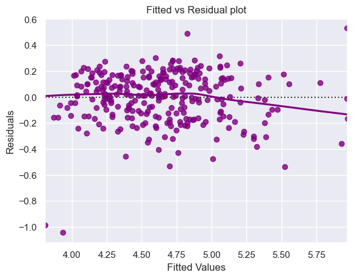

```python
# let's plot the fitted values vs residuals

sns.residplot(
    data=df_pred, x="Fitted Values", y="Residuals", color="purple", lowess=True
)
plt.xlabel("Fitted Values")
plt.ylabel("Residuals")
plt.title("Fitted vs Residual plot")
plt.show()
```

- The scatter plot shows the distribution of residuals (errors) vs fitted values (predicted values).
- If there exist any pattern in this plot, we consider it as signs of non-linearity in the data and a pattern means that the model doesn't capture non-linear effects.
- **We see no pattern in the plot above. Hence, the assumptions of linearity and independence are satisfied.**

### TEST FOR NORMALITY

**Why the test?**

- Error terms, or residuals, should be normally distributed. If the error terms are not normally distributed, confidence intervals of the coefficient estimates may become too wide or narrow. Once confidence interval becomes unstable, it leads to difficulty in estimating coefficients based on minimization of least squares. Non-normality suggests that there are a few unusual data points that must be studied closely to make a better model.

**How to check normality?**

- The shape of the histogram of residuals can give an initial idea about the normality.
- It can also be checked via a Q-Q plot of residuals. If the residuals follow a normal distribution, they will make a straight line plot, otherwise not.
- Other tests to check for normality includes the Shapiro-Wilk test.
  - Null hypothesis: Residuals are normally distributed
  - Alternate hypothesis: Residuals are not normally distributed

**How to fix if this assumption is not followed?**

- We can apply transformations like log, exponential, arcsinh, etc. as per our data.

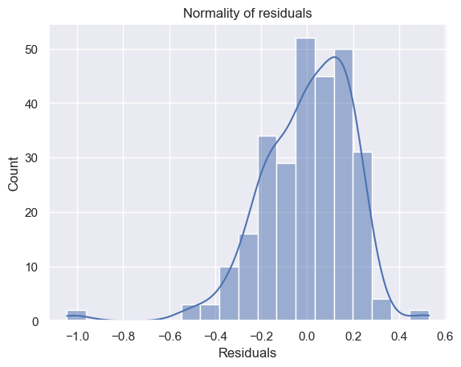

```python
sns.histplot(data=df_pred, x="Residuals", kde=True)
plt.title("Normality of residuals")
plt.show()
```

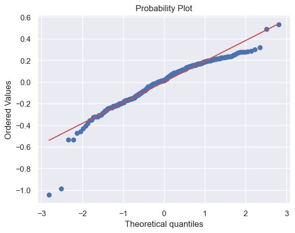

```python
import pylab
import scipy.stats as stats

stats.probplot(df_pred["Residuals"], dist="norm", plot=pylab)
plt.show()
```

- The residuals more or less follow a straight line except for the tails.
- Let's check the results of the Shapiro-Wilk test.

```python
stats.shapiro(df_pred["Residuals"])
```

```
ShapiroResult(statistic=0.9325000047683716, pvalue=5.221761356644095e-10)
```

- Since p-value < 0.05, the residuals are not normal as per the Shapiro-Wilk test.
- Strictly speaking, the residuals are not normal.
- However, as an approximation, we can accept this distribution as close to being normal.
- **So, the assumption is satisfied.**

### TEST FOR HOMOSCEDASTICITY

- **Homoscedascity**: If the variance of the residuals is symmetrically distributed across the regression line, then the data is said to be homoscedastic.
- **Heteroscedascity**: If the variance is unequal for the residuals across the regression line, then the data is said to be heteroscedastic.

**Why the test?**

- The presence of non-constant variance in the error terms results in heteroscedasticity. Generally, non-constant variance arises in presence of outliers.

**How to check for homoscedasticity?**

- The residual vs fitted values plot can be looked at to check for homoscedasticity. In the case of heteroscedasticity, the residuals can form an arrow shape or any other non-symmetrical shape.
- The goldfeldquandt test can also be used. If we get a p-value > 0.05 we can say that the residuals are homoscedastic. Otherwise, they are heteroscedastic.
  - Null hypothesis: Residuals are homoscedastic
  - Alternate hypothesis: Residuals have heteroscedasticity

**How to fix if this assumption is not followed?**

- Heteroscedasticity can be fixed by adding other important features or making transformations.

```python
import statsmodels.stats.api as sms
from statsmodels.compat import lzip

name = ["F statistic", "p-value"]
test = sms.het_goldfeldquandt(df_pred["Residuals"], xt_train3c)
lzip(name, test)
```

```
[('F statistic', 1.5504938053790076), ('p-value', 0.006195316918311555)]
```

## Predictions on test data

```python
# predictions on the test set
pred = olsmodt3c.predict(xt_test3c)

df_pred_test_tablet = pd.DataFrame({"Actual": yt_test, "Predicted": pred})
df_pred_test_tablet.sample(10, random_state=1)
```

|  | Actual | Predicted |
| --- | --- | --- |
| 801 | 4.590 | 4.749 |
| 1721 | 4.298 | 4.618 |
| 1962 | 5.231 | 5.085 |
| 784 | 4.252 | 4.459 |
| 2274 | 4.841 | 4.611 |
| 811 | 4.988 | 4.825 |
| 21 | 4.452 | 4.598 |
| 466 | 4.126 | 4.203 |
| 453 | 4.405 | 4.239 |
| 758 | 4.565 | 4.373 |

- We can observe here that our model has returned pretty good prediction results, and the actual and predicted values are comparable

## Final Model

Let's recreate the final model and print it's summary to gain insights.

```python
xt_train_final = xt_train3c.copy()
xt_test_final = xt_test3c.copy()
```

```python
olsmodelt_final = sm.OLS(yt_train, xt_train_final).fit()
print(olsmodelt_final.summary())
```

```
                              OLS Regression Results
=================================================================================
Dep. Variable:     normalized_used_price   R-squared:                       0.807
Model:                               OLS   Adj. R-squared:                  0.801
Method:                    Least Squares   F-statistic:                     142.3
Date:                   Sun, 18 Jun 2023   Prob (F-statistic):           1.44e-92
Time:                           23:31:21   Log-Likelihood:                 57.172
No. Observations:                    281   AIC:                            -96.34
Df Residuals:                        272   BIC:                            -63.60
Df Model:                              8
Covariance Type:               nonrobust
========================================================================================
                           coef    std err          t      P>|t|      [0.025      0.975]
----------------------------------------------------------------------------------------
main_camera_mp           0.0149      0.005      2.996      0.003       0.005       0.025
int_memory               0.0005      0.000      2.762      0.006       0.000       0.001
ram                      0.0441      0.012      3.658      0.000       0.020       0.068
weight                   0.0013      0.000     11.893      0.000       0.001       0.001
release_year             0.0091      0.007      1.300      0.195      -0.005       0.023
normalized_new_price     0.3575      0.034     10.552      0.000       0.291       0.424
os_iOS                  -0.1906      0.063     -3.017      0.003      -0.315      -0.066
4g_yes                   0.0655      0.033      1.974      0.049       0.000       0.131
const                  -16.4829     14.172     -1.163      0.246     -44.383      11.417
==============================================================================
Omnibus:                       77.746   Durbin-Watson:                   2.068
Prob(Omnibus):                  0.000   Jarque-Bera (JB):              248.766
Skew:                          -1.186   Prob(JB):                     9.58e-55
Kurtosis:                       6.953   Cond. No.                     2.43e+06
==============================================================================

Notes:
[1] Standard Errors assume that the covariance matrix of the errors is correctly specified.
[2] The condition number is large, 2.43e+06. This might indicate that there are
strong multicollinearity or other numerical problems.
```

```python
# checking model performance on train set (seen 70% data)
print("Training Performance\n")
olsmodelt_final_train_perf = model_performance_regression(
    olsmodelt_final, xt_train_final, yt_train
)
olsmodelt_final_train_perf
```

```
Training Performance
```

|  | RMSE | MAE | R-squared | Adj. R-squared | MAPE |
| --- | --- | --- | --- | --- | --- |
| 0 | 0.197 | 0.152 | 0.807 | 0.801 | 3.367 |

```python
# checking model performance on test set (seen 30% data)
print("Test Performance\n")
olsmodelt_final_test_perf = model_performance_regression(
    olsmodelt_final, xt_test_final, yt_test
)
olsmodelt_final_test_perf
```

```
Test Performance
```

|  | RMSE | MAE | R-squared | Adj. R-squared | MAPE |
| --- | --- | --- | --- | --- | --- |
| 0 | 0.191 | 0.152 | 0.838 | 0.825 | 3.196 |

## Actionable Insights and Recommendations Tablet

# Thoughts

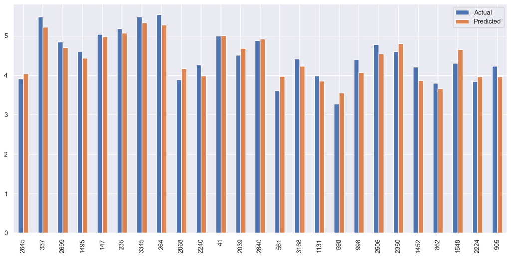

```python
dfp = df_pred_test_phone.sample(25, random_state=1)
dfp.plot(kind="bar", figsize=(15, 7))
plt.show()
```

#### Bar plot above shows the actual and predicted values for phones

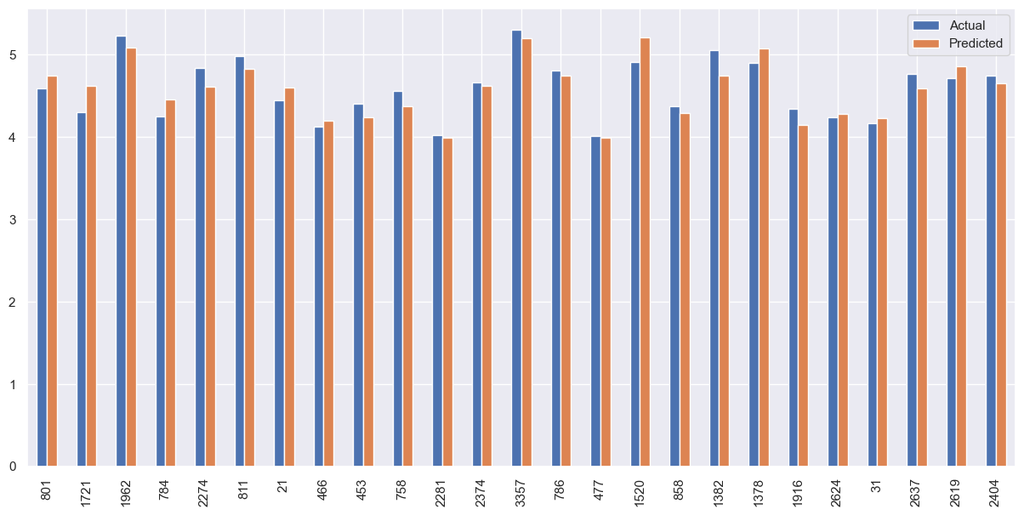

```python
dft = df_pred_test_tablet.sample(25, random_state=1)
dft.plot(kind="bar", figsize=(15, 7))
plt.show()
```